# Statistics and Probability

#### 5.3.0.1 Exercise

Explain the steps of the derivation of the score of the exponential distribution.

**Click for the answer**

We use that the derivative of a sum is the sum of the derivatives. Then the derivative of $\log(\lambda)$ is $1/\lambda$, and the derivative of $\lambda$ is 1.

$~$

Let us visualize this score of the exponential distribution log likelihood.

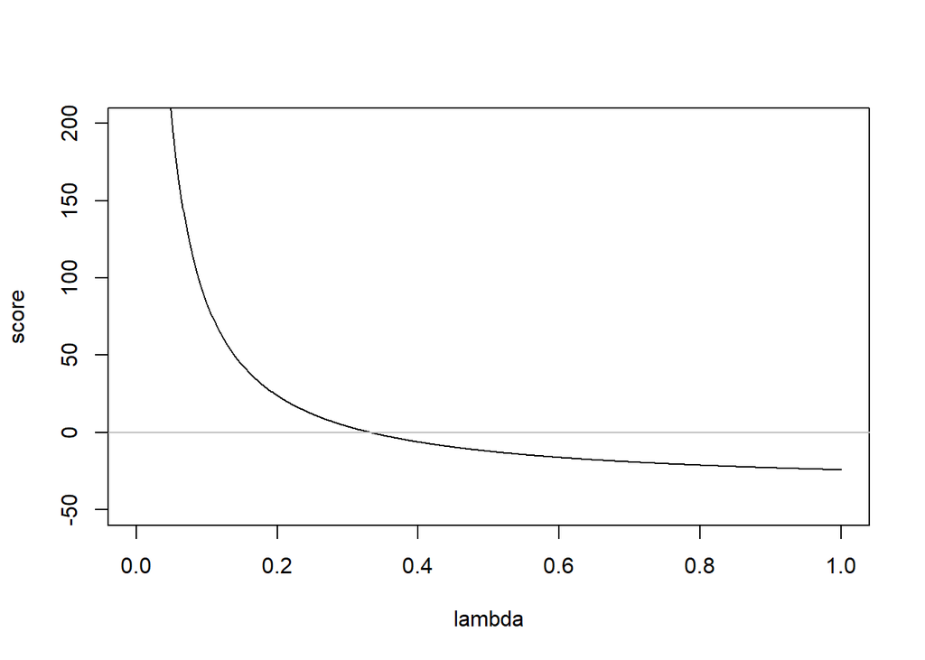

```r
X <- c(1.0, 5.2, 2.1, 9.3, 0.7, 1.5, 2.5, 0.9, 1.0, 3.8, 6.6, 1.6)
score.fun <- function(lambda) length(X)/ lambda - sum(X)
lambda <- seq(0,1,by=0.001)
score <- sapply(lambda, score.fun)
plot(lambda, score, type='l', ylim=c(-50,200))
abline(h=0, col="grey")
```

In this course we will only encounter well-behaved likelihoods that have a single maximum. In this case the score will give useful information:

- score($\lambda$) $>0$: $\lambda$ is below the MLE
- score($\lambda$) $=0$: $\lambda$ is the MLE
- score($\lambda$) $<0$: $\lambda$ is above the MLE

$~$

#### 5.3.0.2 Exercise

We did not mention the quotient rule

$$f(x) = g(x)/h(x) \quad \quad \to \quad f'(x) = \frac{h(x)g'(x) - h'(x)g(x)}{h^2(x)}.$$

Derive this rule by writing $f(x) = g(x)\frac{1}{h(x)}$ and applying the product and chain rules.

**Click for the answer**

Write

$$\begin{align*}
f(x) &= g'(x) \frac{1}{h(x)} + g(x) \Big(\frac{1}{h(x)}\Big)' \\
&= \frac{g'(x)}{h(x)} + g(x) \frac{-1}{h^2(x)} h'(x) \\
&= \frac{g'(x)h(x)}{h^2(x)} - \frac{g(x)h'(x)}{h^2(x)} \\
&= \frac{h(x)g'(x) - g(x)h'(x)}{h^2(x)}
\end{align*}$$

Where we use the product rule in the first step and the chain rule in the second.

$~$

#### 5.3.0.3 Exercise

Calculate the score for the likelihood of $p$ in the Belgian euro experiment with $N=250$.

**Click for the answer**

There are two equivalent ways of viewing this problem. One is as a sequence of Bernoulli trials. The other as a single binomial. Let’s do them both and see that they indeed give the same result.

If we see the coin toss as a sequence of Bernoulli trials, we observe $T = (T_1, \ldots, T_n)$, where each $T_i$ is 0 or 1 depending on whether we observe heads (1) or tails (0). The density is
$$f(x) = p^x(1-p)^{(1-x)},$$
so the log density is
$$\log f(x) = x \log(p) + (1-x) \log(1-p).$$
The log likelihood is
$$\textrm{loglik}(p) = \sum_{i=1}^N \{ t_i \log(p) + (1-t_i) \log(1-p) \} = \log(p) \sum_{i=1}^N t_i + \log(1-p) \sum_{i=1}^N (1-t_i).$$
If $X$ is the number of heads, this is the same as
$$\textrm{loglik}(p) = \log(p) X + \log(1-p) (N-X).$$
The derivative of $\log(p)$ is $1/p$ and the derivative of $\log(1-p)$ is $-1/(1-p)$ by the chain rule, so the score is
$$\textrm{loglik}'(p) = X/p - (N-X)/(1-p).$$

With $N=250$ and $X=140$, this is
$$\textrm{loglik}'(p) = 140/p - 110/(1-p).$$

If, on the other hand we see the experiment as resulting in a single obervation $X$ Binomial distribution with parameters $N$ and $p$, the density is
$$f(x) = {N \choose x} p^x(1-p)^{(N-x)}.$$
The log density is
$$log f(x) = \log {N \choose x} + \log(p) x + \log(1-p) (N-x),$$
so this is also the log likelihood
$$\textrm{loglik}(p) = \log {N \choose x} + \log(p) x + \log(1-p) (N-x).$$
Differentiating with respect to $p$, the first term drops out and we get exactly the same score.

$~$

#### 5.3.0.4 Exercise

Let $X = (0, 3, 3, 4, 2, 0, 1, 4, 0, 4)$ be observations from a Poisson distribution with parameter $\lambda$. Calculate the score as a function of $\lambda$.

**Click for the answer**

The Poisson density is $f(x) = e^{-\lambda} \lambda^x/x!$, so the log density is $\log f(x) = -\lambda + x\log(\lambda) - \log(x!)$. The log likelihood is therefore
$$\mathrm{loglik}(\lambda) = \sum_{i=1}^n \{-\lambda + x_i\log(\lambda) - \log(x_i!)\} \\ =
-n\lambda + \log(\lambda) \sum_{i=1}^n x_i - \sum_{i=1}^n \log(x_i!).$$
Differentiating, we obtain

$$\mathrm{loglik}'(\lambda) =
-n + \lambda^{-1} \sum_{i=1}^n x_i = 21/\lambda - 10.$$

$~$

We can also find the score by doing the differentiation of the log likelihood *numerically*. Remember the definition of the derivative
$$f'(x) = \lim_{t\to 0}\frac{f(x+t)-f(x)}{t}.$$

Numerically, instead of taking $t \to 0$ all the way, we can just take $t$ very small: we divide the increments of the log likelihood by the increments of $\lambda$. The finer a grid you take for lambda, the more accurate the numerical approximation.

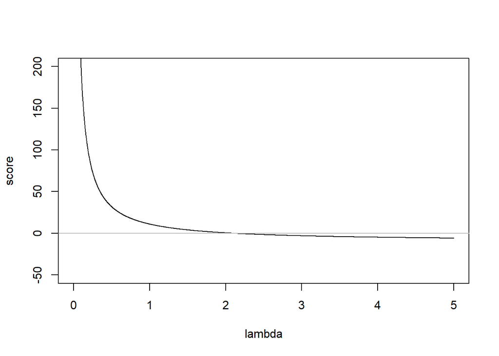

```r
X <- c(0, 3, 3, 4, 2, 0, 1, 4, 0, 4)
loglik.fun <- function(lambda) sum(dpois(X, lambda, log=TRUE))
step <- 0.001
lambda <- seq(0,5,by=step)
loglik <- sapply(lambda, loglik.fun)
score <- diff(loglik)/step
plot(lambda[-length(lambda)], score, type='l', ylim=c(-50,200), xlab='lambda')
abline(h=0, col="grey")
```

We can add the exact score function in red:

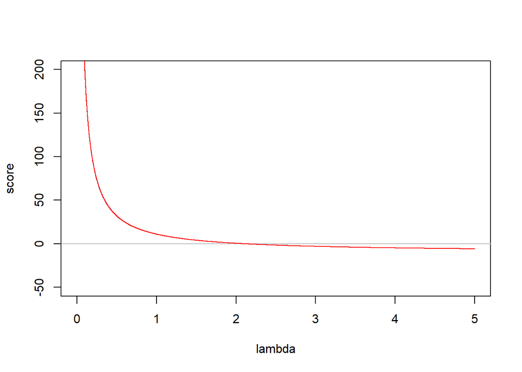

```r
plot(lambda[-length(lambda)], score, type='l', ylim=c(-50,200), xlab='lambda')
abline(h=0, col="grey")
lines(lambda, 21/lambda-10,col="red")  # exact score
```

$~$

#### 5.3.0.5 Exercise

For the Belgian euro experiment, calculate the score numerically, and compare your result to the analytic result you found earlier by plotting the score calculated in both ways.

**Click for the answer**

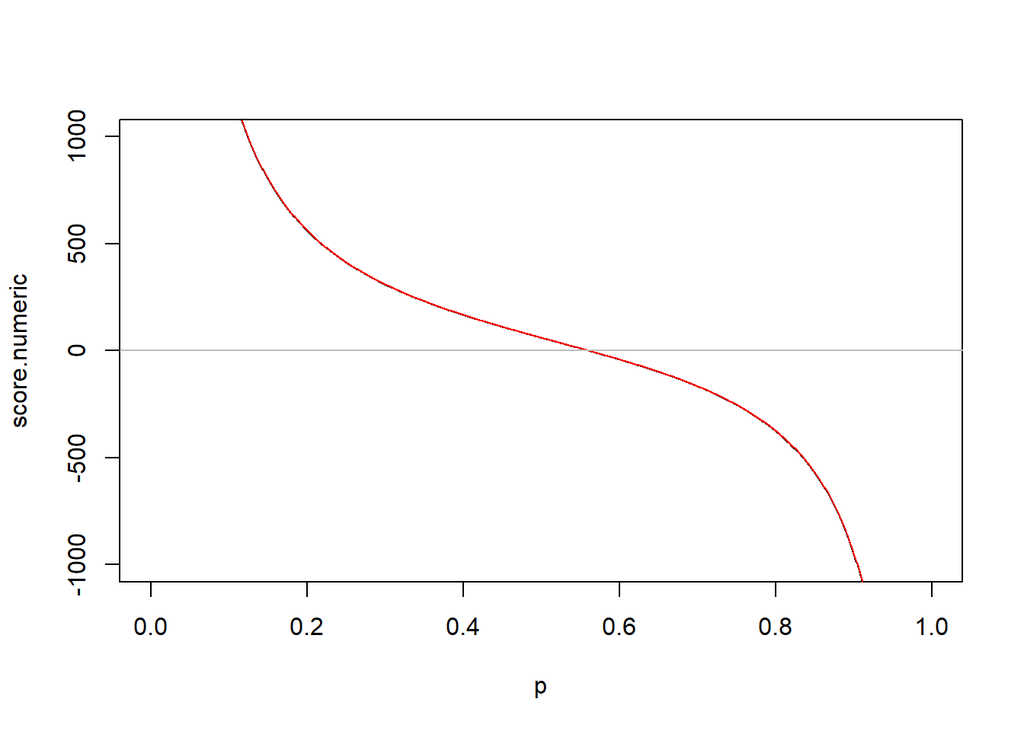

```r
loglik.fun <- function(p) sum(dbinom(140, size=250, prob=p, log=TRUE))
step <- 0.001
p <- seq(0,1,by=step)
loglik <- sapply(p, loglik.fun)
score.numeric <- diff(loglik)/step
score.analytic <- 140/p - 110/(1-p)
plot(p[-length(p)], score.numeric, type='l', xlab='p', ylim=c(-1000,1000))
lines(p, score.analytic, col='red')
abline(h=0, col="grey")
```

$~$

#### 5.3.0.6 Exercise

The following values were oberved from a normal distribution with known mean $\mu=0$ and unknown $\sigma^2$: $X=( 0.06, 0.21, 0.47, -2.48, -0.39, -1.11)$. Calculate and plot the score for $\sigma^2$ numerically. Read off the approximate maximum likelihood estimate from your plot.

**Click for the answer**

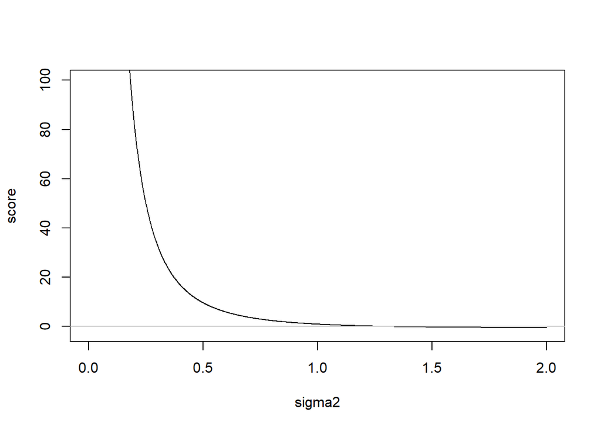

```r
X= c ( 0.06,  0.21,  0.47, -2.48, -0.39, -1.11)
loglik.fun <- function(sig2) sum(dnorm(X, mean=0, sd=sqrt(sig2), log=TRUE))
step <- 0.001
sig2 <- seq(0,2,by=step)
loglik <- sapply(sig2, loglik.fun)
score <- diff(loglik)/step
plot(sig2[-length(sig2)], score, type='l', xlab='sigma2', ylim=c(-2,100))
abline(h=0, col="grey")
```

To read off the MLE you may want to further reduce the ylim, or we calculate something like

```r
sig2[which.min(abs(score))]
```

```
## [1] 1.3
```

$~$

## 5.4 What have we learned?

- We can calculate the MLE analytically
- We can calculate score analytically and numerically.
- We can use the score to find maximum likelihood estimators.

# 6 Large Sample Theory

When the sample size is large, many statistical calculations simplify. In this lecture we explain why that is so. In practice, we must often rely on these simplifications because otherwise the calculations are just too difficult. Of course, this is only valid if our sample size is “large enough”.

## 6.1 LLN and CLT

For statistics, the two most important results of probability theory are the Law of Large Numbers (LLN) and the Central Limit Theorem (CLT).

$~$

#### 6.1.0.1 Exercise

Run the following script *at least* 10 times and comment what you see.

```r
x=rnorm(100,2,1)
xbar=cumsum(x)/(1:100)     # check: ?cumsum
plot(1:100,xbar,type="l")
abline(h=2)
```

**Click for the answer**

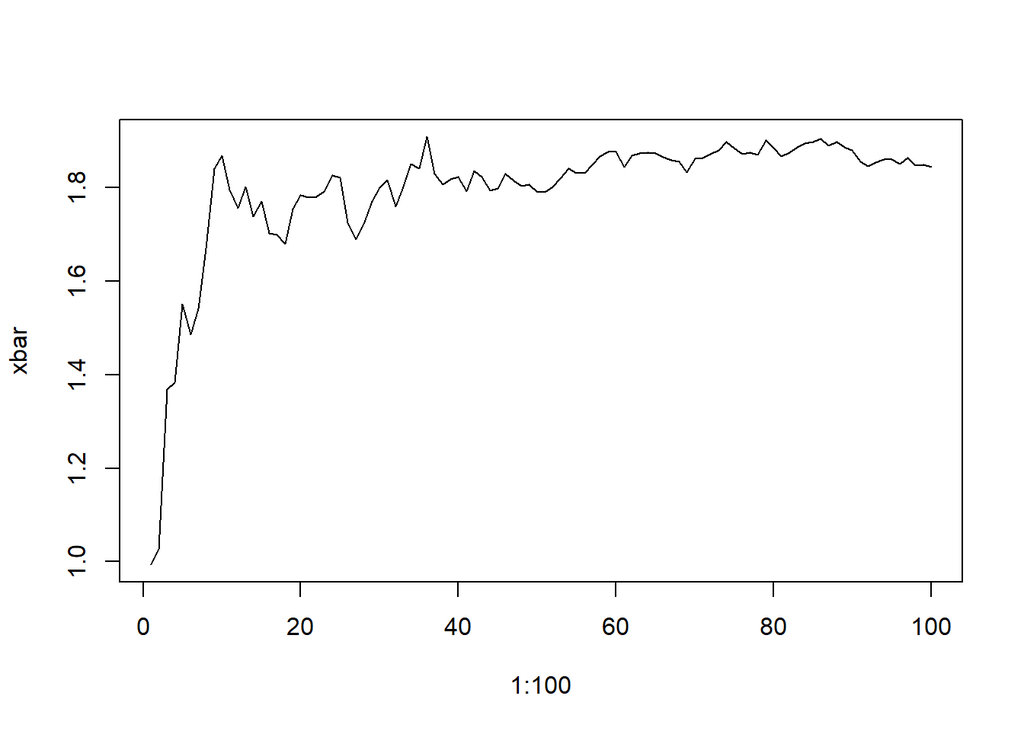

$~$

The LLN says that averages converge to means (expected values). We have used the LLN to motivate the method of moments. Since many estimators (inclusing MLEs) are *basically* just averages, the LLN often implies that an estimator converges to the true parameter as the sample size increases. This is called “consistency” or asymptotic unbiasedness. Here , asymptotic means “for very large sample size”. Consistency is often viewed as the minimal requirement for a sensible estimator.

The Central Limit Theorem is a deeper result than the LLN. The CLT says that sums and averages become normally distributed. This means that as the sample size increases, many different estimation problems start to resemble estimating the simple situation of estimating the mean of a normal distribution by the sample average. The following exercise demonstrates the CLT.

$~$

#### 6.1.0.2 Exercise

1. Use `runif` to generate a sample of size 10^5 from the standard uniform distribution, and make a histogram.
2. Generate another sample of size 10^5 from the standard uniform distribution, and add this to your first sample. Again, make a histogram.
3. Generate another sample of size 10^5 from the standard uniform distribution, and add this to the first two samples. Again, make a histogram.
4. Keep going!

**Click for the answer**

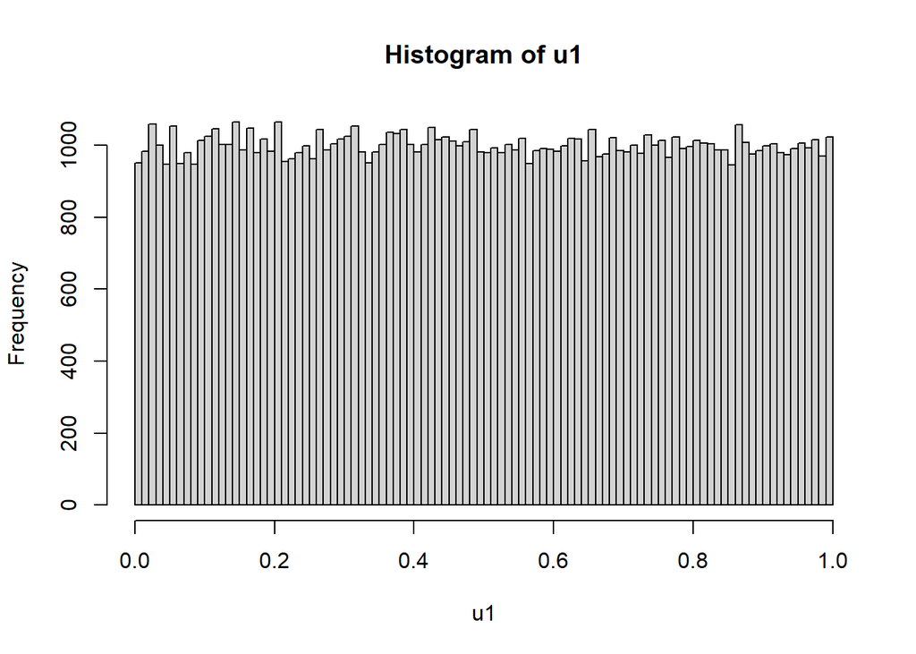

```r
u1=runif(10^5)
hist(u1,100)
```

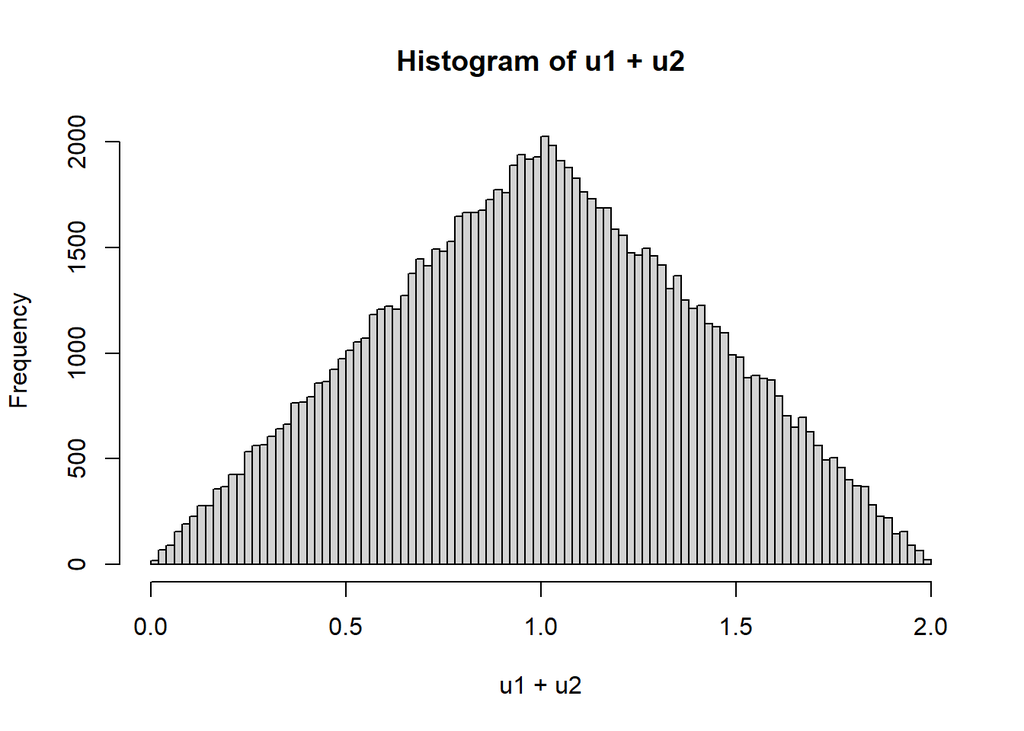

```r
u2=runif(10^5)
hist(u1+u2,100)
```

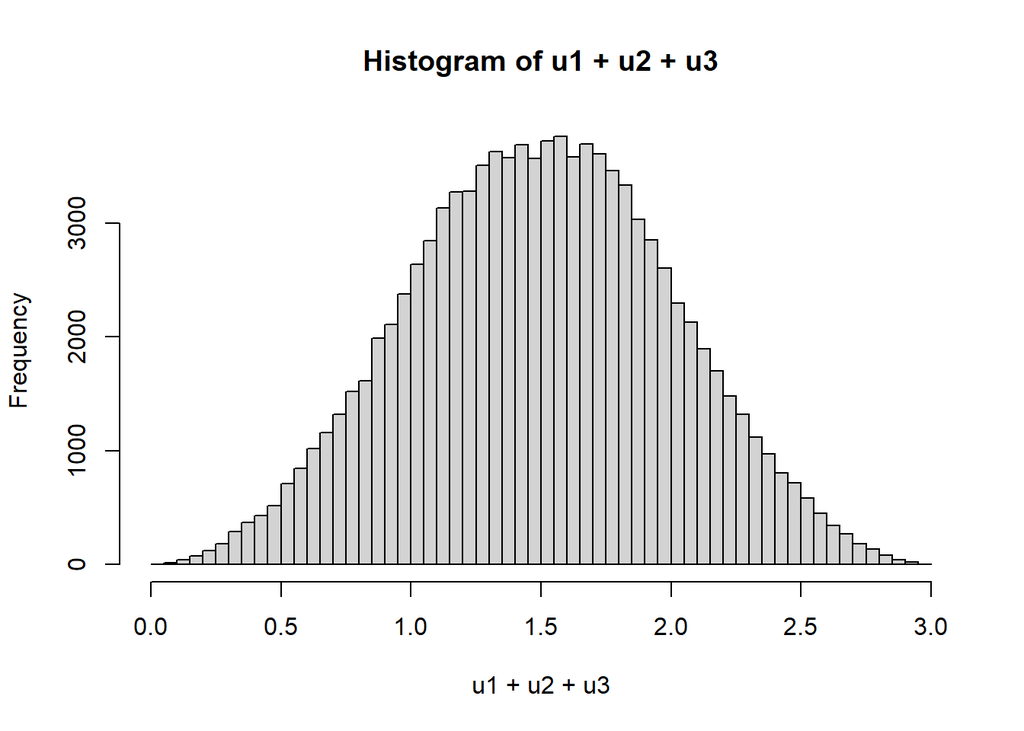

```r
u3=runif(10^5)
hist(u1+u2+u3,100)
```

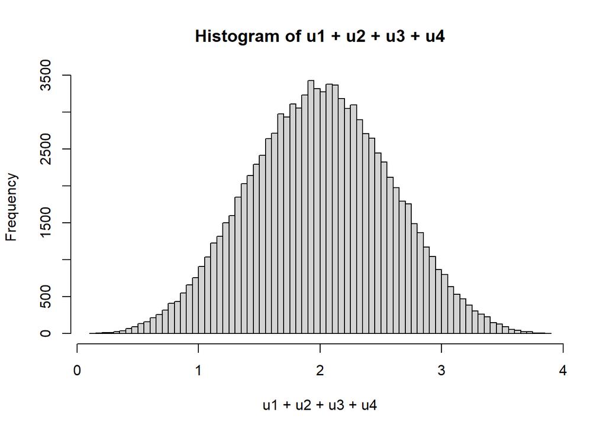

```r
u4=runif(10^5)
hist(u1+u2+u3+u4,100)
```

After just 3 or 4 steps, we see the normal bell curve appear. This illustrates the Central Limit Theorem.

$~$

$~$

#### 6.1.0.3 Exercise

Try the same steps as the previous exercise, but now use the exponential distribution.

**Click for the answer**

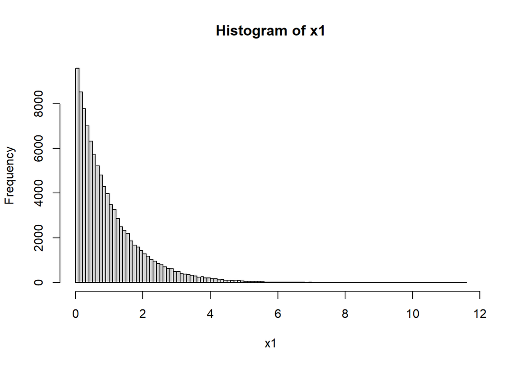

```r
x1=rexp(10^5)
hist(x1,100)
```

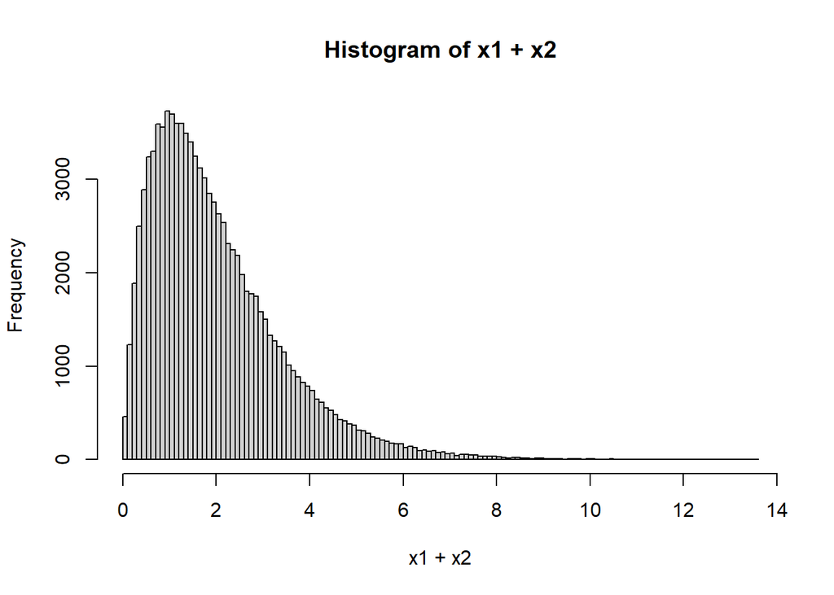

```r
x2=rexp(10^5)
hist(x1+x2,100)
```

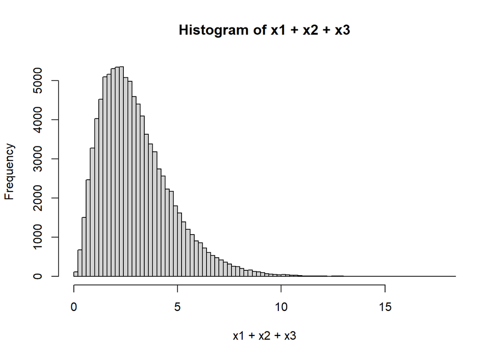

```r
x3=rexp(10^5)
hist(x1+x2+x3,100)
```

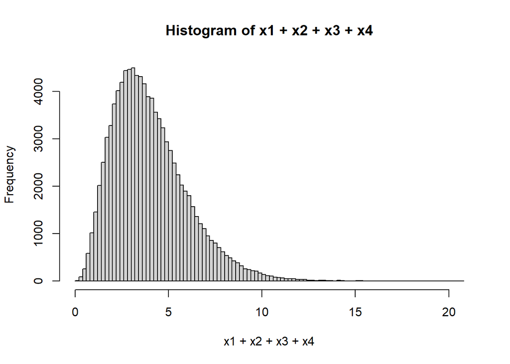

```r
x4=rexp(10^5)
hist(x1+x2+x3+x4,100)
```

Again, you can see the normal bell curve appear, but much slower than with the uniform distribution. This is due to the fact that the exponential distribution is so heavily skewed.

$~$

## 6.2 Estimating the mean of a normal distribution

Many “regular” estimators are basically just averages of some sort. The LLN tells us that averages converge to the expected value and therefore many estimators converge to the true parameter. The CLT tells us that averages become normally distributed as the sample size increases. This means that many estimators start to behave like the sample average of a normal distribution. So, let us look more closely at this archetype of statistical estimation.

Suppose we have an i.i.d. sample $X_1,X_2,\dots,X_n$ from a normal distribution with unknown mean $\mu$ and known standard deviation $\sigma$. We can run a little simulation by choosing $n=12$, $\mu=2$ and $\sigma=1$. We plot the log likelihood.

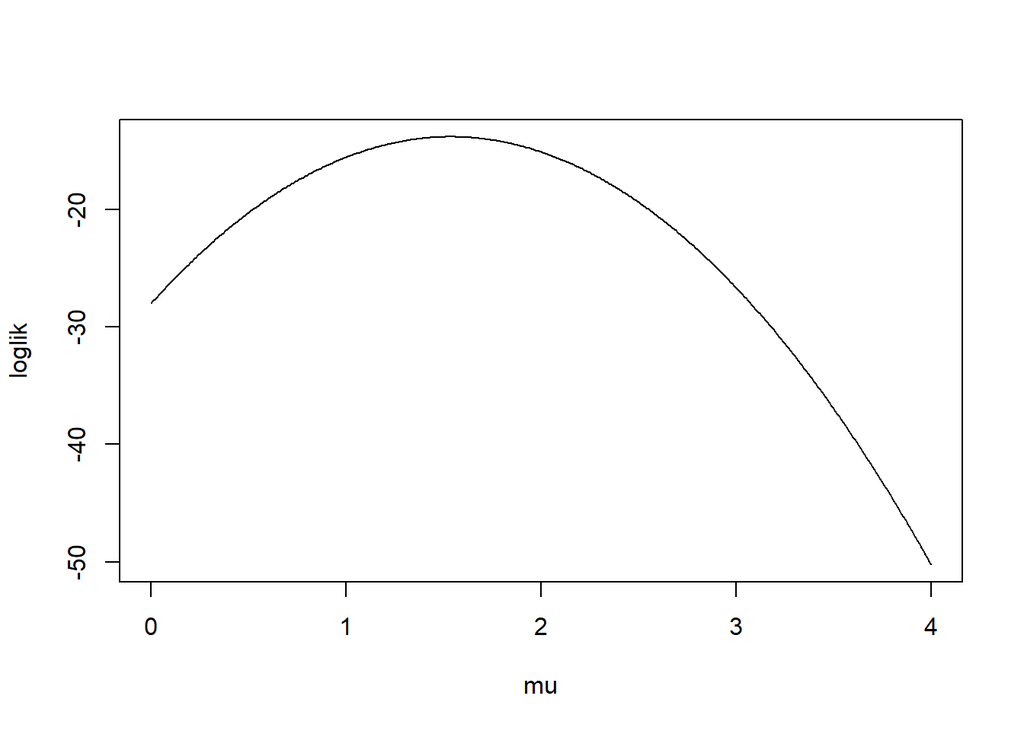

```r
X <- rnorm(12, mean=2, sd=1)
loglik.fun <- function(mu) sum(log(dnorm(X, mean=mu, sd=1)))
mu <- seq(0,4,by=0.01)
loglik <- sapply(mu, loglik.fun)
plot(mu, loglik, type='l')
```

The log likelihood of the normal mean looks like a parabola (= quadratic function), and in fact it is! We can derive this analytically. Remember that the normal density is

$$f(x) = \frac{1}{\sqrt{2\pi\sigma^2}} e^{-\frac{1}{2\sigma^2}(x-\mu)^2},$$
and so

$$\begin{align*}
\log f(x) &= \log \frac{1}{\sqrt{2\pi\sigma^2}} + \log \Big(e^{-\frac{1}{2\sigma^2}(x-\mu)^2}\Big) \\
&= -\frac12 \log(2\pi\sigma^2) - \frac{1}{2\sigma^2}(x-\mu)^2 \\
&= -\frac{1}{2\sigma^2} \mu^2 + \frac{x}{\sigma^2}\mu - \frac{x^2}{2\sigma^2} - \frac12 \log(2\pi\sigma^2).
\end{align*}$$
We see that the log density of a normal distribution is a parabola in $\mu$ because is has the form $A \mu^2 + B\mu +C$.

$~$

#### 6.2.0.1 Exercise

Explain the steps in this calculation.

**Click for the answer**

$~$

The log likelihood is also a parabola:

$$\begin{align*}
\mathrm{loglik}(\mu)
&= \sum_{i=1}^n \Big( -\frac{1}{2\sigma^2} \mu^2 + \frac{x_i}{\sigma^2}\mu - \frac{x_i^2}{2\sigma^2} - \frac12 \log(2\pi\sigma^2)\Big) \\
&= -\frac{n}{2\sigma^2} \mu^2 + \frac{\sum_{i=1}^n x_i}{\sigma^2}\mu - \frac{\sum_{i=1}^n x_i^2}{2\sigma^2} - \frac n2 \log(2\pi\sigma^2)
\end{align*}$$

So, the log likelihood also has the form $A\mu^2 + B\mu + C$. This a unique property of the normal distribution, and it will turn out to be very important.

Parabolas were covered very prominently in your secondary school. What do you remember?

- If $A<0$, the parabola has a maximum.
- The location of that maximum is at $-\frac{B}{2A}$.
- If $|A|$ is large, the function is very peaked, if $|A|$ is small, it is flat

$~$

#### 6.2.0.2 Exercise

- Check that $A<0$.
- Check that the location of maximum of the log likelihood at $-B/(2A)$ is equal to $\bar X$.
- What determines whether the normal log likelihood is very peaked?

**Click for the answer**

- $A = -\frac{n}{2\sigma^2} < 0$
- The MLE is at the maximum of the log likelihood, which is at -B/(2A). So,
  $$\hat\mu=-B/(2A) = -\frac{\sum_{i=1}^n x_i}{\sigma^2} /\Big(-\frac{2n}{2\sigma^2}\Big) = \frac{\sum_{i=1}^n x_i}{n} = \bar X$$
- $|A|=\frac{n}{2\sigma^2}$. So the log likelihood is peaked when $n$ is large and/or $\sigma^2$ is small.

$~$

We discussed derivatives of the log likelihood before. The *score function* is the first derivative of the log likelihood. In this case, the score is

$$\mathrm{loglik}'(\mu) = -\frac{n}{\sigma^2} \mu + \frac{\sum_{i=1}^n x_i}{\sigma^2}$$
We can find the MLE of $\mu$ by setting the score equal to zero, and then we find $\hat \mu = \bar X = \frac 1n \sum_{i=1}^n x_i$. The second derivative is also very important.

$$\mathrm{loglik}''(\mu) = -\frac{n}{\sigma^2}.$$
The first derivative is the rate of change of a function. So, the second derivative is the rate of change of the first derivative. In this case, it tells us how curved or “peaked” the log likelihood is. $~$

#### 6.2.0.3 Exercise

Let us look at the log likelihood for different values of $n$ and $\sigma$. Run the following code for n=5,10,20 and 100, and sd=1,2 and 5.

```r
n=5
sd=1
X <- rnorm(n=n, mean=0, sd=sd)
loglik.fun <- function(mu) sum(log(dnorm(X, mean=mu, sd=sd)))
mu <- seq(-10,10,by=0.01)
loglik <- sapply(mu, loglik.fun)
plot(mu, loglik, type='l',xlim=c(-10,10),ylim=c(-200,10))
```

**Click for the answer**

Note that the log likelihood is more “peaked” when $n$ is large and/or $\sigma$ is small.

$~$

If we have few data points ($n$ is small) or our data are very noisy ($\sigma$ is large) then we do not have very much information to estimate $\mu$. In that case, the log likelihood is very flat so that values close to the MLE all have similar likelihood. That means we cannot tell those values for $\mu$ apart on the basis of our data. In other words: the MLE is not well localized.

The following statements are different ways of saying the same thing about estimating the mean of a normal distribution:

- The sample size ($n$) is small and the data are very noisy ($\sigma$ is large).
- We do not have much information about $\mu$.
- Minus the second derivative of the log likelihood is small.
- The log likelihood is very flat.
- The MLE is not well localized.

With this in mind, the definition of the *Fisher information* of a parameter $\theta$ should make sense. The *Fisher information* is often denote by $\cal I(\theta)$, and it is defined as the expectation of minus the second derivative of the log likelihood
$$\textrm{Fisher Information}(\theta) = \cal I(\theta) = \mathrm{E}(-\mathrm{loglik}''(\theta)).$$
We take the expectation because in general the log likelihood and its second derivative are random (they depend on the data). The (random) quantity $I(\theta) = -\mathrm{loglik}''(\theta)$ is called the *observed* Fisher information.

Now, in the special case of estimating the mean of a normal distribution the second derivative of the log likelihood does *not* depend on the data. In fact, it does not even depend on $\mu$! We have
$${\cal I}(\mu) = I(\mu) = \frac{n}{\sigma^2}.$$

#### 6.2.0.4 Exercise

The expression for $\cal I(\mu)$ may not immediately be meaningful to you, but if you take $1/\cal I(\mu)$, does that look familiar? Or $1/\sqrt{\cal I (\mu)}$? Where have you encountered that expression before?

**Click for the answer**

$1/\sqrt{\cal I}(\mu) = \sigma/\sqrt{n}$ is the standard error of the mean $\hat\mu$.

$~$

#### 6.2.0.5 Exercise

Calculate the mean and standard deviation of $\hat \mu = \frac1n \sum_{i=1}^n x_i$ if $x_1, \ldots, x_n$ are iid normal with parameters $\mu$ and $\sigma^2$ (i.e. the standard error). What is the distribution of $\hat\mu$?

**Click for the answer**

$$\mathrm{E}\Big( n^{-1}\sum_{i=1}^n x_i \Big) = \frac1n \sum_{i=1}^n \mathrm{E}(x_i) = \mu \\
\mathrm{Var}\Big( n^{-1}\sum_{i=1}^n x_i \Big) = \frac{1}{n^2}\sum_{i=1}^n \mathrm{Var}(x_i) = \sigma^2/n,$$
Where the last calculation uses the fact that $x_1,\ldots, x_n$ are independent.

Because the sum of independent normally distributed variables is normal, $\hat\mu$ is also normal with mean $\mu$ and variance $\sigma^2/n$.

$~$

The Fisher Information is a very useful tool. It describes the amount of information there is in the likelihood (and therefore in the data) about the parameter. The larger the Fisher information, the more peaked the log likelihood, and the more precisely we can estimate the parameter.

## 6.3 Calculating the Fisher Information

The second derivative of the log likelihood governs how peaked the log likelihood is. Let’s calculate the second derivative for the exponential log likelihood. Recall that the density of the exponential distribution is
$$f_\lambda(x) = \lambda e^{-\lambda x} \qquad$$
where $\lambda>0$ is the “rate”. If $X$ has the exponential distribution, then the expected value is $E(X)=1/\lambda$. If we have an i.i.d. sample then the score function (=derivative of the log likelihood) is
$$\mathrm{loglik}'(\lambda) = \frac{n}{\lambda} - \sum_{i=1}^n x_i.$$
Setting the score function equal to zero, we find the MLE $\hat \lambda = 1/\bar X$. Differentiating again, we find the second derivative of the log likelihood
$$\mathrm{loglik}''(\lambda) = -\frac{n}{\lambda^2}.$$

Since $\mathrm{loglik}''(\lambda)$ does not depend on the data, the Fisher Information ${\cal I}(\lambda)=\mathrm{E}[-\mathrm{loglik}''(\lambda)]$ is equal to the *observed* Fisher information $I(\lambda) = -\mathrm{loglik}''(\lambda)$. We have
$${\cal I}(\lambda) = I(\lambda) = \mathrm{E}[-\mathrm{loglik}''(\lambda)] = \frac{n}{\lambda^2}$$

$~$

We see that the Fisher information $n/\lambda^2$ decreases steeply as $\lambda$ increases, but increases with $n$. We learn from this (1) that larger sample sizes will have more information and give more accurate estimates and (2) that large values of $\lambda$ have *less* information and are more difficult to estimate precisely.

#### 6.3.0.1 Exercise

Calculate the observed Fisher information and the Fisher information for for a single draw $X$ from the binomial distribution with known sample size $n$ and unknown probability of success $p$. Is there a difference between observed Fisher information and Fisher information?

**Click for the answer**

We found the score as
$$\mathrm{loglik}'(p) = \frac{X}{p} - \frac{N-X}{1-p}.$$
Differentiating, we get the observed Fisher information
$$\mathrm{loglik}''(p) = -\frac{X}{p^2} - \frac{N-X}{(1-p)^2}.$$
This still depends on the data, so the *observed* Fisher information is
$$I(p) = -\mathrm{loglik}''(p) = \frac{X}{p^2} + \frac{N-X}{(1-p)^2}.$$

Since this depends on the data, there is a difference with the Fisher information. We calculate that as
$$\begin{align*}
{\cal I}(p) = \mathrm{E}[-\mathrm{loglik}''(p)] &= \frac{\mathrm{E}(X)}{p^2} + \frac{N-\mathrm{E}(X)}{(1-p)^2} \\
&= \frac{Np}{p^2} + \frac{N(1-p)}{(1-p)^2} \\
&= \frac{N}{p} + \frac{N}{(1-p)} \\
&= \frac{N(1-p)}{p(1-p)} + \frac{Np}{p(1-p)} \\
&= \frac{N}{p(1-p)}.
\end{align*}$$

$~$

#### 6.3.0.2 Exercise

Let $X = (0, 3, 3, 4, 2, 0, 1, 4, 0, 4)$ be observations from a Poisson distribution with parameter $\lambda$. Calculate the Fisher Information analytically.

**Click for the answer**

We found the score as
$$\mathrm{loglik}'(\lambda) =
-n + \lambda^{-1} \sum_{i=1}^n x_i.$$
Differentiating, we get the observed Fisher information
$$\mathrm{loglik}''(\lambda) = -\lambda^{-2} \sum_{i=1}^n x_i.$$
This still depends on the data, so there is a difference between observed Fisher Information and Fisher information. We calculate the latter as
$$\mathrm{E}[-\mathrm{loglik}''(\lambda)] = \lambda^{-2} \mathrm{E}\Big[\sum_{i=1}^n x_i\Big]
= \lambda^{-2} n\lambda = n/\lambda.$$

$~$

Like the score, we can calculate the observed Fisher Information numerically, simply by numerically differentiating twice.

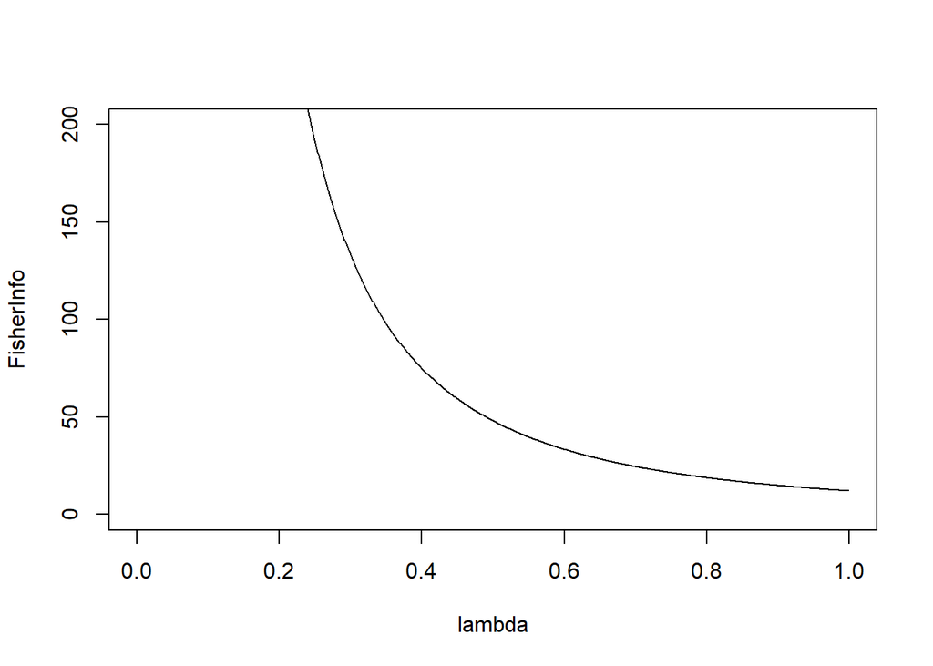

```r
X <- c(1.0, 5.2, 2.1, 9.3, 0.7, 1.5, 2.5, 0.9, 1.0, 3.8, 6.6, 1.6)
loglik.fun <- function(lambda) sum(dexp(X, rate=lambda, log=TRUE))
step <- 0.001
lambda <- seq(0,1,by=step)
loglik <- sapply(lambda, loglik.fun)
score <- diff(loglik)/step
FisherInfo <- -diff(score)/step
plot(lambda[-c(1,length(lambda))], FisherInfo, type='l', ylim=c(0,200),
     xlab = 'lambda')
```

Alternatively, we can use the function `hessian` from the numDeriv package which computes the second derivative of a function.

```r
library(numDeriv)
X <- c(1.0, 5.2, 2.1, 9.3, 0.7, 1.5, 2.5, 0.9, 1.0, 3.8, 6.6, 1.6)
loglik.fun <- function(lambda) sum(dexp(X, rate=lambda, log=TRUE))
lambda <- seq(0.1,1,by=0.01)
H=sapply(lambda, function(lambda) hessian(loglik.fun,lambda))
FisherInfo=-H   # Observed Fisher information = - second derivative of the score (log lik)
plot(lambda, FisherInfo, type='l', ylim=c(0,200), xlab = 'lambda')
```

$~$

#### 6.3.0.3 Exercise

Let $X = (0, 3, 3, 4, 2, 0, 1, 4, 0, 4)$ be observations from a Poisson distribution with parameter $\lambda$. Calculate and plot the observed Fisher information numerically.

**Click for the answer**

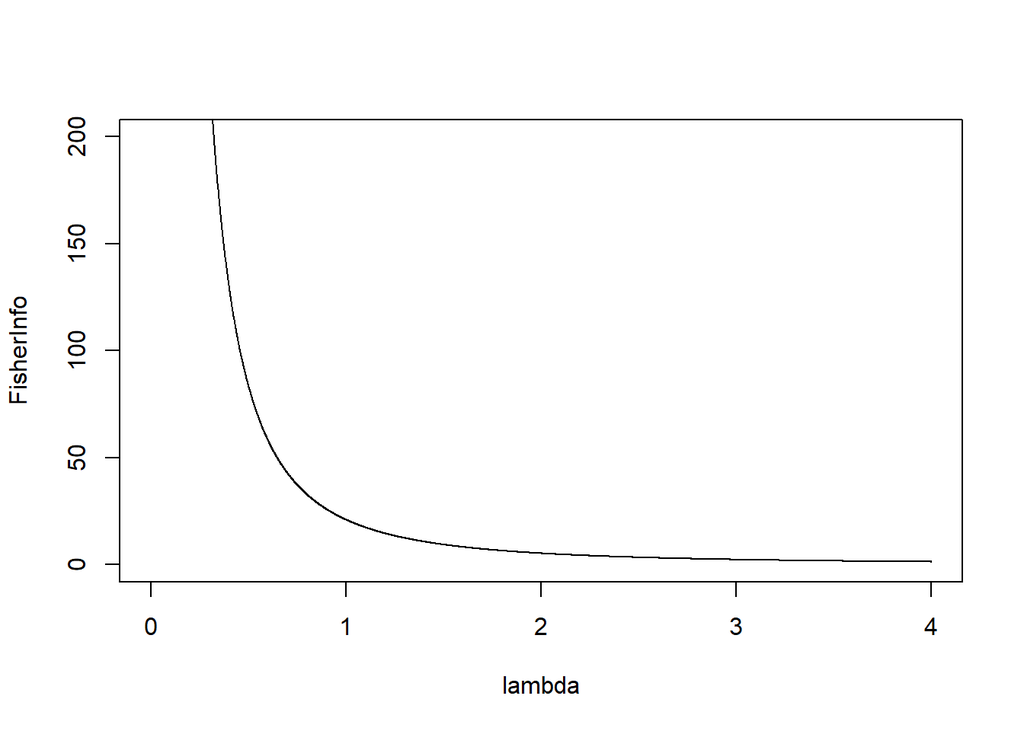

```r
X <- c(0, 3, 3, 4, 2, 0, 1, 4, 0, 4)
loglik.fun <- function(lambda) sum(dpois(X, lambda=lambda, log=TRUE))
step <- 0.001
lambda <- seq(0,4,by=step)
loglik <- sapply(lambda, loglik.fun)
score <- diff(loglik)/step
FisherInfo <- -diff(score)/step
plot(lambda[-c(1,length(lambda))], FisherInfo, type='l', ylim=c(0,200),
     xlab = 'lambda')
```

Alternatively, using `hessian`

```r
X <- c(0, 3, 3, 4, 2, 0, 1, 4, 0, 4)
loglik.fun <- function(lambda) sum(dpois(X, lambda=lambda, log=TRUE))
lambda <- seq(0.01,4,by=0.01)
H=sapply(lambda, function(lambda) hessian(loglik.fun,lambda))
FisherInfo=-H   # Observed Fisher information = - second derivative of the score (log lik)
plot(lambda, FisherInfo, type='l', ylim=c(0,200), xlab = 'lambda')
```

$~$

#### 6.3.0.4 Exercise

The following values were oberved from a normal distribution with known mean $\mu=0$ and unknown $\sigma^2$: $X=( 0.06, 0.21, 0.47, -2.48, -0.39, -1.11)$. Calculate the observed Fisher Information for $\sigma^2$, and plot it.

**Click for the answer**

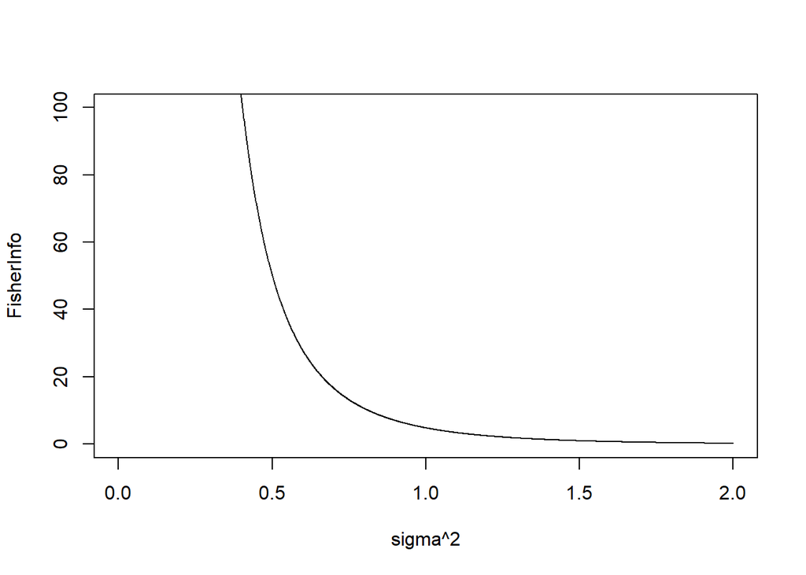

```r
X= c ( 0.06,  0.21,  0.47, -2.48, -0.39, -1.11)
loglik.fun <- function(sig2) sum(dnorm(X, mean=0, sd=sqrt(sig2), log=TRUE))
step <- 0.001
sig2 <- seq(0,2,by=step)
loglik <- sapply(sig2, loglik.fun)
score <- diff(loglik)/step
FisherInfo <- -diff(score)/step
plot(sig2[-c(1,length(sig2))], FisherInfo, type='l', xlab='sigma^2', ylim=c(0,100))
```

Alternatively, using `hessian`

```r
X= c ( 0.06,  0.21,  0.47, -2.48, -0.39, -1.11)
loglik.fun <- function(sig2) sum(dnorm(X, mean=0, sd=sqrt(sig2), log=TRUE))
sig2 <- seq(0.01,2,by=0.01)
H=sapply(sig2, function(sig2) hessian(loglik.fun,sig2))
FisherInfo=-H   # Observed Fisher information = - second derivative of the score (log lik)
plot(sig2, FisherInfo, type='l', xlab = 'sigma^2', ylim=c(0,100))
```

$~$

## 6.4 Large sample theory

The Central Limit Theorem says that if some random variable is the sum of many random variables, its distribution will tend towards the normal distribution. The CLT also works on the log likelihood itself, which is random and (in case of independent observations) the sum of many terms, one for each subject.

$$\text{loglik}(\theta) = \sum_{i=1}^N \log f_\theta(X_i).$$

The CLT also works on important quantities that we calculate from the log likelihood, such as the MLE and the Fisher information.

#### 6.4.0.1 Exercise

Explain using the law of large numbers that the observed Fisher Information, divided by $N$, gets closer and closer to the Fisher Information, divided by $N$, as $N$ increases. Hint: write the observed Fisher Information as a sum of many terms.

**Click for the answer**

The log likelihood is $\text{loglik}(\theta) = \sum_{i=1}^N \log f_\theta(X_i)$. Because the derivative of a sum is a sum of derivatives, the observed Fisher information is
$$I(\theta) = -\text{loglik}''(\theta) = - \sum_{i=1}^N \log f_\theta''(X_i)$$

where ’’ here means derivation with respect to the parameter $\theta$. By the LLN we have that the average of i.i.d. random variables converges to its expectation, so
$$\begin{align*}
\frac1N I(\theta) = - \frac1N \sum_{i=1}^N \log f_\theta''(X_i) \rightarrow & - E\left[\log f_\theta''(X_1)\right] \\
& = - \frac1N\sum_{i=1}^N E\left[ \log f_\theta''(X_i)\right] \\
& = - \frac1N E\left[\sum_{i=1}^N \log f_\theta''(X_i)\right]\\
& = \frac1N E[-\text{loglik}''(\theta)] = \frac1N {\cal I}(\theta).
\end{align*}$$

$~$

So, loosely speaking, if the sample size is large, everything we would calculate starts to look like it comes from a normal distribution likelihood.

We already know that estimates get more and more accurate as the sample size increases but how do we see this in the log likelihood? Let’s compare the log likelihood for the *same* estimate ($\hat p = 14/25=0.56$) for sample sizes of 25, 250, 2500, 25000…

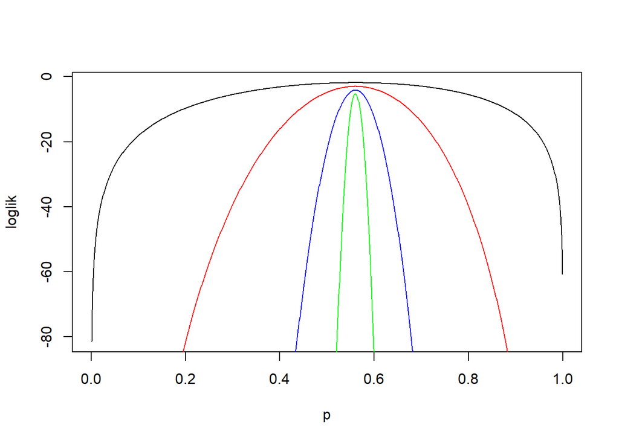

```r
loglik.fun25 <- function(p) dbinom(14, size = 25, prob=p, log=TRUE)
loglik.fun250 <- function(p) dbinom(140, size = 250, prob=p, log=TRUE)
loglik.fun2500 <- function(p) dbinom(1400, size = 2500, prob=p, log=TRUE)
loglik.fun25000 <- function(p) dbinom(14000, size = 25000, prob=p, log=TRUE)
p <- seq(0,1,by=0.001)
plot(p, loglik.fun25(p), type='l', ylab='loglik')
lines(p, loglik.fun250(p), col='red')
lines(p, loglik.fun2500(p), col='blue')
lines(p, loglik.fun25000(p), col='green')
```

What do we notice? First, while the top of the log likelihood remains in the same place at 0.56, the log likelihood becomes much more “peaked”. With larger sample size, the log likelihood drops much more steeply as we move away from the maximum. Take for example the value $p=0.6$. The log likelihood of that value is about the same as that of the MLE of $0.56$ when $N=25$, a bit smaller when $N=250$, substantially smaller when $N=2500$, and a lot smaller if $N=25000$. The more peaked the log likelihood is, the better it is able to distinguish between likely and less likely values of the parameter $p$. Intuitively, this means that a peaked log likelihood gives more accurate estimates.

Second, we see that as $N$ increases, the log likelihood looks more and more like a parabola. In the example, the log likelihood is already very much like a parabola when $N=250$. This phenomenon is not specific to the binomial log likelihood we use here, but holds for all well-behaved log likelihoods (we’ll discuss what that well-behaved means later). This means that for large $N$, rather than writing down a complicated log likelihood, we may instead write down a much simpler one: the log likelihood function of a normal distribution!

Let us consider another example. Suppose we have an i.i.d. sample from the exponential distribution. We generate some data for different sample sizes, and plot the log likelihood. Note that we align the log likelihood functions vertically, so that we can compare them more easily.

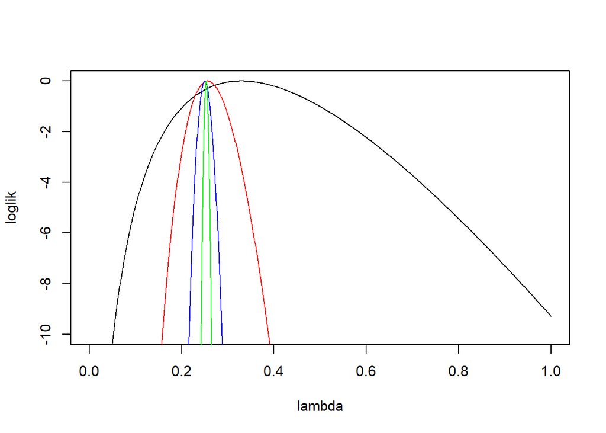

```r
set.seed(1234)
X <- rexp(1e4, rate=1/4)
loglik.fun <- function(lambda, N) sum(dexp(X[1:N], rate=lambda, log=TRUE))
lambda <- seq(0,1,by=0.001)
loglik1 <- sapply(lambda, loglik.fun, N=10)
loglik2 <- sapply(lambda, loglik.fun, N=1e2)
loglik3 <- sapply(lambda, loglik.fun, N=1e3)
loglik4 <- sapply(lambda, loglik.fun, N=1e4)
plot(lambda, loglik1-max(loglik1), type='l', ylab='loglik', ylim=c(-10,0))
lines(lambda, loglik2-max(loglik2), col='red')
lines(lambda, loglik3-max(loglik3), col='blue')
lines(lambda, loglik4-max(loglik4), col='green')
```

Notice how, as the sample size $N$ increases, the log likelihood

- becomes more and more peaked, *and*
- starts to look more and more like a parabola.

The log likelihood summarizes all the information we have to estimate some parameter. If the log likelihood looks very much like a parabola, and the parabola is the log likelihood of the mean of a normal distribution, then it follows that our estimation problem looks very much like estimating the mean of a normal distribution. This is a general principle, for which we will see many more applications later in this course.

One of the most important aspects we can “borrow” from the normal distribution likelihood is the distribution of the MLE. Remember that in a normal model, the MLE $\hat\mu = \bar X$ has a normal distribution with mean $\mu$ and variance equal to $\sigma^2/n = 1/\cal I(\lambda)$.

What holds for the normal mean also holds for other well-behaved MLEs. If the sample size is large (we say: “asymptotically”) we have for the MLE $\hat \theta$ of a parameter $\theta$

> - The MLE $\hat \theta$ is asymptotically unbiased (i.e. “consistent”)
> - The MLE $\hat \theta$ is asymptotically normal with mean $\theta$
> - The asymptotic variance of the MLE is $1/\cal I(\theta)$

The asymptotic variance may depend on the true $\theta$ which is unknown. That is not a major problem in practice. We can simply plug in the MLE $\hat\theta$ as we did with the bootstrap. So, for large $N$, we can approximate the asymptotic variance of the MLE by $1/\cal I(\hat \theta)$.

We will now demonstrate the asymptotic distribution of the MLE. Suppose, again, that we have an i.i.d. sample $X_1,X_2,\dots,X_N$ from the exponential distribution and we want to estimate the rate parameter $\lambda$. As we have seen, the exponential likelihood is indistinguishable from a normal likelihood if $N$ is large.

So, for large $N$, the distribution of the MLE $\hat\lambda=1/\bar X$ converges to a normal distribution with mean $\lambda$ and variance $1/{\cal I} (\lambda)= \lambda^2/N$. We call this the *asymptotic distribution* of $\hat\lambda$.

Let’s compare the true (simulated) distribution of the MLE $\hat \lambda$ to the asymptotic distribution in an example.

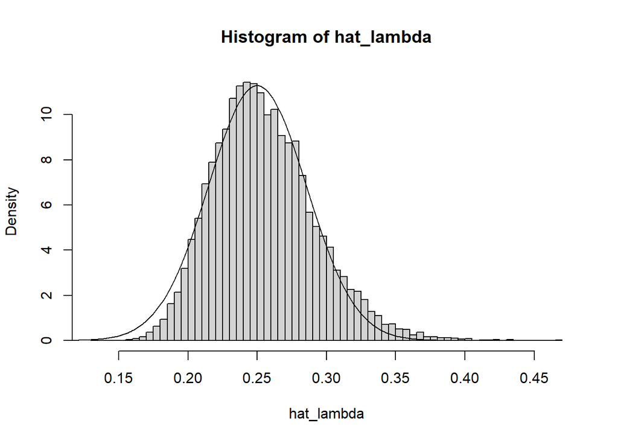

```r
true_lambda <- 1/4
N <- 50
K <- 1e4
hat_lambda <- numeric(true_lambda)
for (i in 1:K) {
  X <- rexp(N, rate = 1/4)
  hat_lambda[i] <- 1/mean(X)
}
asymptotic_mean <- true_lambda
asymptotic_sd <- sqrt(true_lambda^2/N)
hist(hat_lambda, 100, prob=TRUE)           # simulated distribution of the MLE
x=seq(0.1,0.4,0.001)
lines(x,dnorm(x, asymptotic_mean, asymptotic_sd))  # asymptotic (normal) distr.
```

$~$

#### 6.4.0.2 Exercise

Both the simulated distribution (histogram) and the asymptotic normal distribution are approximations to the *true* distribution of $\hat \lambda$.

1. How can we make the asymptotic distribution more accurate?
2. How can we make the simulated distribution more accurate?

**Click for the answer**

The asymptotic distribution becomes more accurate as the sample size ($N$) increases. The simulated distribution becomes more accurate as the number of simulation iterations ($K$) increases.

$~$

#### 6.4.0.3 Exercise

Repeat the comparison between the simulated and asymptotic distributions for different values of $N$. From what value of $N$ would you say that the correspondence between the distributions is good?

**Click for the answer**

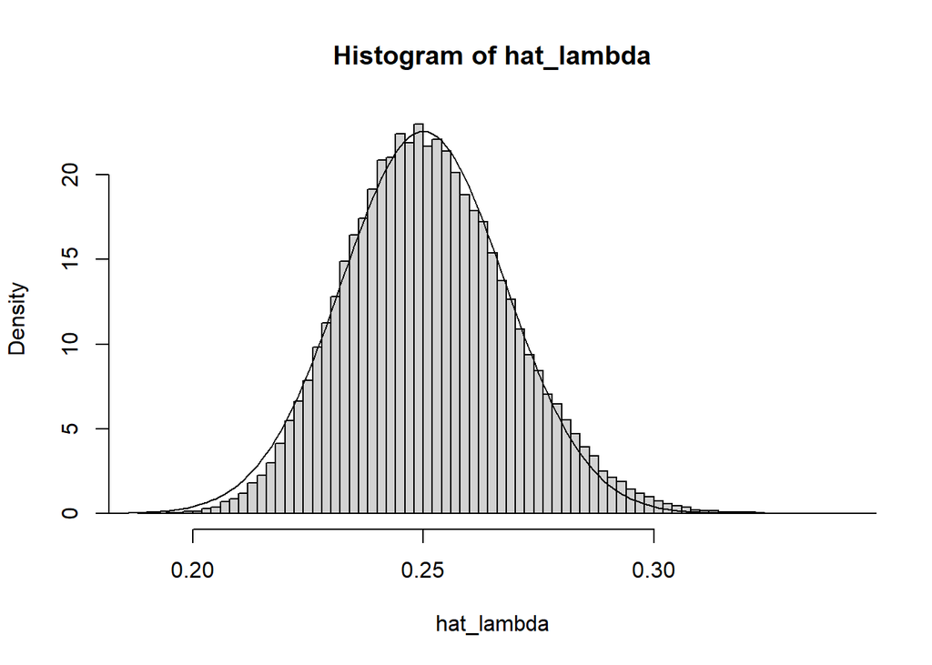

```r
true_lambda <- 1/4
N <- 200
K <- 1e5
hat_lambda <- numeric(K)
for (i in 1:K) {
  X <- rexp(N, rate = 1/4)
  hat_lambda[i] <- 1/mean(X)
}
asymptotic_mean <- true_lambda
asymptotic_sd <- sqrt(true_lambda^2/N)
hist(hat_lambda, 100, prob=TRUE)
x=seq(0.1,0.4,0.001)
lines(x,dnorm(x, asymptotic_mean, asymptotic_sd))
```

There is no right answer to the minimal number $N$ needed because it depends on the application. From around 200 the fit is certainly quite good, although if you are interested in the extreme tails it may still not be good enough.

$~$

#### 6.4.0.4 Exercise

Suppose the Belgian euro coin is unbiased $p=0.5$. What is the asymptotic sampling distribution of its estimate if we toss it $N=250$ times? According to this asymptotic distribution, what is the probability that we find $\hat p > 0.56$?

**Click for the answer**

We found the Fisher Information to be $N/\{p(1-p)\}$. Asymptotically, $\hat p$ is normally distributed with mean $p = 0.5$ and variance $p(1-p)/N = 0.5^2/250$. We calculate

```r
pnorm(0.56, mean=0.5, sd = sqrt(0.5^2/250), lower.tail=FALSE)
```

```
## [1] 0.02888979
```

$~$

#### 6.4.0.5 Exercise

Suppose the Belgian euro coin is unbiased with $p=0.5$. Draw the simulated and the asymptotic distribution for the experiment of tossing the coin $N=250$ times. Are the two distributions alike? Redraw, varying $N$. From which value of $N$ do you think the correspondence between the distributions is excellent?

**Click for the answer**

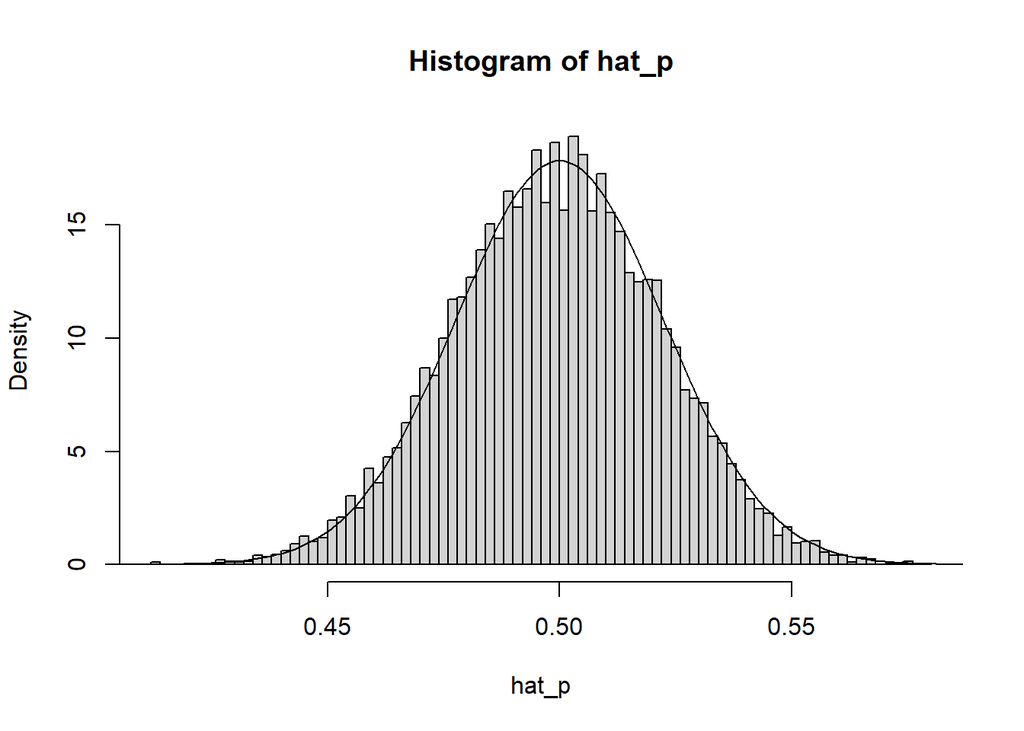

```r
true_p <- 1/2
N <- 500
K <- 1e4
hat_p <- numeric(K)
for (i in 1:K) {
  X <- rbinom(1, size =N, prob = true_p)
  hat_p[i] <- X/N
}
asymptotic_mean <- true_p
asymptotic_sd <- sqrt(true_p*(1-true_p)/N)
hist(hat_p, 100, prob=TRUE)
x=seq(0.4,0.6,0.001)
lines(x,dnorm(x, asymptotic_mean, asymptotic_sd))
```

$~$

For very easy problems, we can calculate the Fisher information analytically by differentiation. In more complicated situations, we can do the calculation numerically. Remember that we only need to calculate the Fisher Information at the MLE. As before, we can use the `diff` function twice, or we can use the function `hessian` from the numDeriv package.

```r
X <- c(1.0, 5.2, 2.1, 9.3, 0.7, 1.5, 2.5, 0.9, 1.0, 3.8, 6.6, 1.6)
loglik.fun <- function(lambda) sum(dexp(X, rate=lambda, log=TRUE))
step <- 0.0001
hat_lambda <- 1/mean(X)
grid <- hat_lambda + c(-step,0,step)   # we make a small grid around the MLE
loglik <- sapply(grid, loglik.fun)
score <- diff(loglik)/step
FisherInfo <- -diff(score)/step
FisherInfo
```

```
## [1] 109.2033
```

Alternatively, use `hessian`

```r
H=hessian(loglik.fun,hat_lambda)
FisherInfo=-H
FisherInfo
```

```
##          [,1]
## [1,] 109.2033
```

```r
#compare the analytic result
N <- length(X)
N/hat_lambda^2
```

```
## [1] 109.2033
```

$~$

#### 6.4.0.6 Exercise

Explain what happens in the R code above.

**Click for the answer**

By calculating the log likelihood in the MLE itself and a small step below and above, we have a small grid around the MLE. Then we can take the difference and obtain the score just before and just after the MLE. Then taking the difference between these two scores, we obtain the second derivative.

$~$

#### 6.4.0.7 Exercise

Numerically calculate the Fisher Information in the MLE of the Belgian euro experiment, where $140$ heads were observed out of $250$ tosses.

**Click for the answer**

```r
X <- 140
N <- 250
loglik.fun <- function(p) sum(dbinom(140, size=250, prob=p, log=TRUE))
step <- 0.0001
hat_p <- X/N
grid <- hat_p + c(-step,0,step)   # we make a small grid around the MLE
loglik <- sapply(grid, loglik.fun)
score <- diff(loglik)/step
FisherInfo <- -diff(score)/step
FisherInfo
```

```
## [1] 1014.61
```

```r
# with hessian
H=hessian(loglik.fun,hat_p)
FisherInfo=-H
FisherInfo
```

```
##         [,1]
## [1,] 1014.61
```

$~$

#### 6.4.0.8 Exercise

**Click for the answer**

```r
X = c(9.99,  0.65, 31.93,  8.39,  0.58,  0.08)
loglik.fun <- function(mu) sum(dlnorm(X, meanlog=mu, sdlog=1, log=TRUE))
hat_mu <- optimize(loglik.fun, c(-3,3), maximum = TRUE)$maximum
hat_mu
```

```
## [1] 0.7318221
```

```r
step <- 0.0001
grid <- hat_mu + c(-step,0,step)   # we make a small grid around the MLE
loglik <- sapply(grid, loglik.fun)
score <- diff(loglik)/step
FisherInfo <- -diff(score)/step
FisherInfo
```

```
## [1] 6
```

```r
# with hessian
H=hessian(loglik.fun,hat_mu)
FisherInfo=-H
FisherInfo
```

```
##      [,1]
## [1,]    6
```

We find that the MLE $\hat\mu$ is asymptotically normal with mean $0.73$ and standard error approximately $1/\sqrt{6}$.

$~$

Asymptotic results such as the one we discussed about the distribution of the MLE are useful when the sample is “large”. How large should $N$ be for the results to be used? There is no hard-and-fast results here, but some considerations and rules-of-thumb.

The consideration is that the more the distribution of the data differs from normality, the longer it takes (i.e. the larger $N$ needs to be) for the distribution of the MLE to be similar to a normal distribution. Distributions tend to take long to converge if they are very skewed or have extreme outliers. For example, the exponential distribution with $\lambda = 1/4$ we used as an example is very skewed, and it takes a relatively long time for the MLE to become nearly normal. We saw above that at $N=50$ the distribution of the MLE was still appreciably different from a normal.

On the other hand, if a distribution is compact with few outliers, convergence to normality will be quick, as we have seen in the Belgian euro exercise above, with a binomial distribution with $p=0.5$.

A reasonable rule of thumb might be that for most data distributions (not too skewed and not too many outliers) asymptotic approximations work quite well already when $N=30$. Highly skewed distributions such as he exponential example will need about $N=100$. For symmetric and compact distributions, $N=10$ may already suffice. These are just loose guidelines of course; as with any approximation in statistics you must always check whether it is accurate enough in your data for the purposes you want to use it for.

## 6.5 Well-behaved likelihoods

All the theory we have given depends on the likelihood being “well-behaved”. This notion has to remain slightly vague or this would turn into a mathematical statistics course, but we will give you some intuition.

Let’s first have a look at an example of a not-so-well-behaved likelihood.

$~$

#### 6.5.0.1 Exercise

Suppose our data are distributed according to a uniform distribution with parameters 0 and $\theta$. Simulate $1000$ data points with a true value of $\theta=1$ and plot the log likelihood. Is it anything like a parabola?

**Click for the answer**

```r
X = runif(1e3, 0, 1)
loglik.fun <- function(theta) sum(dunif(X, 0, theta, log=TRUE))
grid <- seq(0,2,by=0.001)
loglik <- sapply(grid, loglik.fun)
```

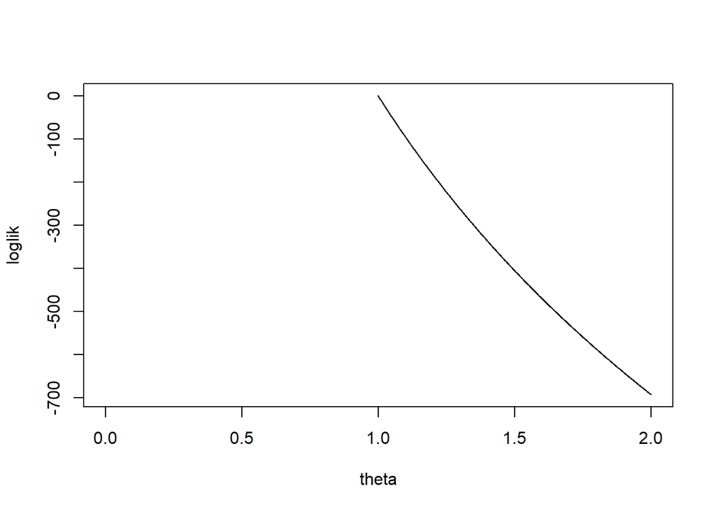

```r
plot(grid, loglik, type='l', xlab='theta')
```

Clearly nothing like a parabola.

$~$

We see that the log likelihood is not at all like a parabola. In general, loosely speaking, a likelihood is well-behaved if

- the likelihood is sufficiently smooth around the value of the true parameter
- the true value of the parameter is not at the edge of the parameter space

The uniform likelihood is an example that does not fulfil the first case: the (log) likelihood is not smooth, but has a sharp peak at $\max(X_1, \ldots, X_n)$. An example of a likelihood not fulfilling the second case would be a normal likelihood when the true value of $\sigma^2$ is 0.

With the exception of the uniform distribution, all models we’ve seen in this course lead to well-behaved likelihoods. The same holds for virtually all models that are frequently used in applied statistics. In this course, you may assume that every likelihood is well-behaved. If it isn’t (and it matters for the exercise), we’ll say so.

## 6.6 What have we learned?

- We can describe the log likelihood of the normal distribution as a parabola.
- We can use the asymptotic approximation to the log likelihood.
- We can calculate the asymptotic distribution of maximum likelihood estimators.
- We can explain the relationship between the Fisher Information and the peakedness of the log likelihood

# 7 Hypothesis testing

## 7.1 A fair coin?

A fair coin is such that when tossed, it comes up heads with probability 1/2. When the euro was introduced in 2002, Tomasz Gliszczynski and Waclaw Zawadowski, statistics teachers at the Akademia Podlaska in Siedlce tossed (or rather spun, to be precise) a Polish euro 10,000 times and did not find anything out of the ordinary. However, after flipping a Belgian euro $n=250$ times, they found that it came up heads 140 times! They ascribe this deviation from 125 to the “portly” king Albert displayed on the Belgian euro (New Scientist, January 4, 2002).

#### 7.1.0.1 Exercise

As a statistician, you must be able to assess the evidence for a claim. So, based on the data that were collected by the two researchers *and* your common sense, do you think the Belgian euro is fair?

**Click for the answer**

We’ll see ;)

$~$

How should we decide this question? It is clear that – even if the coin is fair – getting *exactly* 125 heads in 250 tosses is unlikely. So *some* deviation from 125 is to be expected. It is also clear that if the coin is fair, getting 240 heads is virtually impossible. Getting 240 heads in 250 tosses surely makes it very doubtful that the coin is fair.

#### 7.1.0.2 Exercise

Use ${\tt binom}$ to compute the probabilities of the two events mentioned above.

**Click for the answer**

```r
dbinom(125,250,0.5)
```

```
## [1] 0.05041221
```

```r
dbinom(240,250,0.5)
```

```
## [1] 1.210475e-58
```

$~$

The *only* logical approach is to declare the coin unfair, if the deviation from 125 is larger than some cut-off. In other words, declare the coin unfair if $|X-125|$ exceeds some cut-off.

#### 7.1.0.3 Exercise

$\dots$ or can you think of some other method?

**Click for the answer**

Any reasonable method you can think of is probably equivalent to checking if |X-125| is large.

$~$

In statistical jargon, we have the following situation. Suppose $X$ is distributed according to the Binomial distribution with sample size $n=250$ and unknown $p$. We want to test the *null hypothesis*
$$H_0: p=1/2$$
versus the *alternative*
$$A: p\neq 1/2.$$
We *reject* $H_0$ if $|X-125|$ exceeds some cut-off $K$.

In this case, $|X-125|$ is the *test statistic* and the cut-off $K$ is its *critical value*. We still need to determine an appropriate value for $K$ – we’ll get to that later.

The null hypothesis always represents the status quo or “nothing to report”. We reject it if there is enough evidence in favour of the alternative. If there is not enough evidence, then the null hypothesis gets the benefit of the doubt.

In other words, if we cannot reject the null hypothesis then we may *not* conclude that it is true. It only means that we do not have enough reason to doubt it. It can happen that the null hypothesis is totally false, but our sample size is too small to prove it.

**Analogy** Think of a court case. The accused (null hypothesis) is considered innocent until proven guilty.

The founding father of modern statistics, R.A. Fisher said it like this:

> “The null hypothesis is never proved or established, but only disproved. ($\dots$) Every experiment may be said to exist only in order to give the facts a chance of disproving the null hypothesis.”

Our experiment to decide if a coin is fair is as follows: Flip the coin 250 times and record the number of heads $X$. Reject the null hypothesis if $|X-125| > K$. That is, we reject the null hypothesis if either $X<125-K$ or $X>125+K$. We still need to decide on an appropriate value of $K$.

Below we show the probability that $|X-125| > K$ (for some $K$) when the null hypothesis is true ($p=0.5$) and when it is false ($p=0.6$). We see that if the null hypothesis is true, the probability to reject (red region) is quite small. When the null hypothesis is false, that probability is much larger.

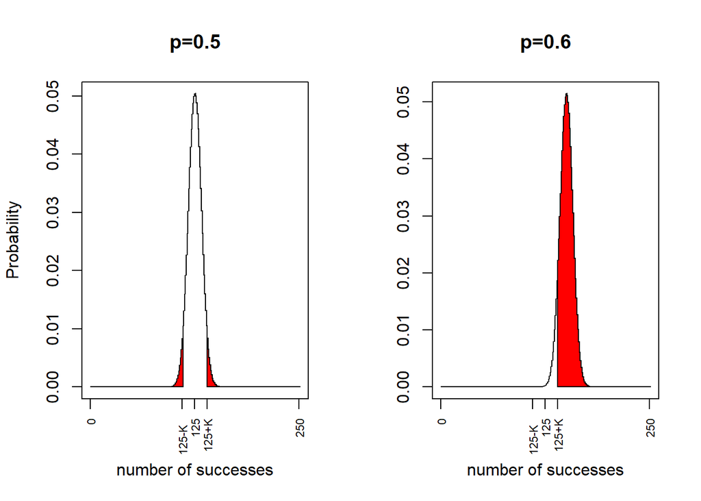

Now, this procedure can lead to two types of mistakes:

- type I error: null hypothesis is true, but you reject it.
- type II error: null hypothesis is *not* true, but you fail to reject it.

The probability of making a type I error is called the *level of significance* of the test and it is often denoted with the Greek letter $\alpha$. It is sometimes even referred to as the $\alpha$ level.

#### 7.1.0.4 Exercise

Suppose we toss a coin 250 times and observe $X$ heads. We reject the null hypothesis if $|X-125|>K$.

1. Use ${\tt pbinom}$ to determine the level of significance when $K=5$, $K=10$ and $K=20$.
2. Use simulation to determine the level of significance when $K=5$, $K=10$ and $K=20$.

**Click for the answer**

1. We have to compute the probability that we reject H0 (p=1/2) when it is true.

```r
K=5
pbinom(125-K-1,250,1/2) + 1 - pbinom(125+K,250,1/2)
```

```
## [1] 0.4866918
```

2. Now use simulation. We approximate a probability with a frequency.

```r
reject=0
for (i in 1:10000){
  x=rbinom(1,250,1/2)
  reject=reject + (abs(x-125) > K)
}
reject/10000
```

```
## [1] 0.4906
```

You can do K=10 and K=20 yourself!

$~$

Of course, we would like the probability of committing either error to be zero, but this is usually not possible – you can never exclude bad luck! However, we do have some control over the two types of error. By increasing $K$, we can decrease the chance of a type I error. Unfortunately, this is at the expense of increasing the chance of a type II error.

**Analogy** Think of a fire alarm. If it is too sensitive, it goes off whenever you use the toaster. If it is too insensitive (after you get annoyed and take out the battery), the house might burn down without the alarm going off.

#### 7.1.0.5 Exercise

True or false: probability of a type I error = (1 $-$ probability of a type II error).

**Click for the answer**

This is absolutely not true!

- probability of a type I error = probability of rejecting H_0 when it is true.
- probability of a type II error = 1 - probability of rejecting H_0 when it is false.

$~$ So the type I and II errors are about different situations; what happens when H0 is true versus what happens when it is false.

$~$

Our choice for the cut-off $K$ should really depend on the consequences of making a type I error or a type II error. However, in many situations, the scientific community simply insists that the probability of a type I error (level of significance) must not exceed 0.05.

#### 7.1.0.6 Exercise

Suppose all statistical tests are done at the 5% level. Does that imply that not more than 5% of all significant results are false positives?

**Click for the answer**

No! Consider two conditional probabilities

- P( reject H0 | H0 is true) versus
- P(H0 is true | reject H0)

By testing at the 5% level, we ensure that the first probability is not more than 5%. But this says *nothing* about the second probability.

$~$ In general, P(A | B) and P(B | A) are very different things! For example, think of A = person is female and B = person has breast cancer. Then P(A | B) is very large, but - fortunately - P(B | A) not.

$~$

#### 7.1.0.7 Exercise

In our coin tossing experiment, use ${\tt pbinom}$ to determine the smallest $K$ such that the level of significance does not exceed $\alpha=0.05$. Repeat the Exercise for $\alpha=0.01$ and $\alpha=0.1$.

**Click for the answer**

Here is a rather silly way; just check all the possible cut-offs

```r
for (K in 0:25){
   alpha=pbinom(125-K-1,250,1/2) + 1 - pbinom(125+K,250,1/2)  # probability to reject
                                                              # H0 when H0 is true
   cat(K,alpha,'\n')
}
```

```
## 0 0.9495878
## 1 0.8495636
## 2 0.7519021
## 3 0.6580555
## 4 0.5693014
## 5 0.4866918
## 6 0.4110189
## 7 0.3427987
## 8 0.2822724
## 9 0.2294249
## 10 0.1840151
## 11 0.1456172
## 12 0.1136656
## 13 0.08750233
## 14 0.06642115
## 15 0.04970679
## 16 0.03666721
## 17 0.02665796
## 18 0.01909853
## 19 0.01348145
## 20 0.00937517
## 21 0.006422025
## 22 0.004332724
## 23 0.002878684
## 24 0.001883301
## 25 0.001213076
```

So, the smallest value for K such that the level of significance does not exceed 5% is K=15.

- Similarly, K=20 is the smallest such that the level of significance does not exceed 1%.
- Similarly, K=13 is the smallest such that the level of significance does not exceed 10%.

$~$

Trying out different values for $K$ to determine the appropriate critical value is not the most practical way. We want to find the smallest $K$ such that
$$P({\rm reject}\ H_0) = P(|X - 125| > K) \leq 0.05$$
when the null hypothesis ($p=1/2$) is true. The distribution of the test statistic $|X-125|$ under the null hypothesis is not easy. But we can use simulation!

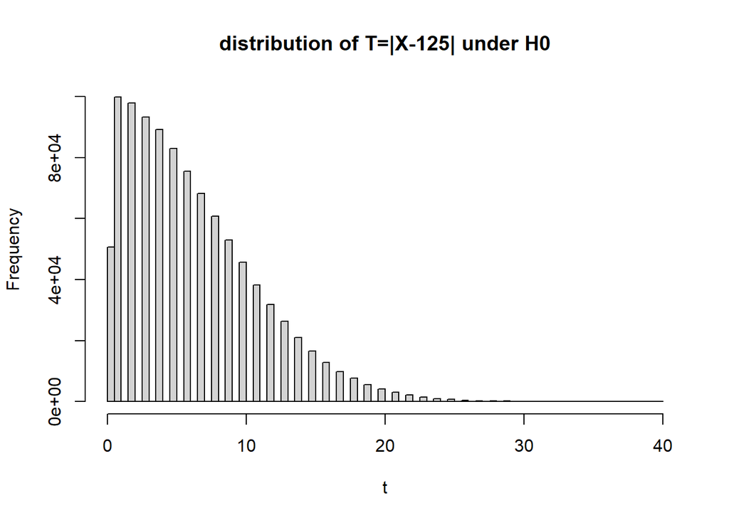

```r
x=rbinom(10^6,250,1/2)
t=abs(x-125)
hist(t,100,main="distribution of T=|X-125| under H0")
```

Now, we can find $K$ as follows:

```r
t=sort(t)
K=t[950000]
K
```

```
## [1] 15
```

R has a built-in function that makes this even easier:

```r
quantile(t,0.95)
```

```
## 95%
##  15
```

#### 7.1.0.8 Exercise

Use simulation to determine the smallest $K$ such that the level of significance does not exceed $\alpha=0.01$ and $\alpha=0.1$.

**Click for the answer**

```r
x=rbinom(10^6,250,p=1/2)
t=abs(x-125)
quantile(t,0.99)
```

```
## 99%
##  20
```

```r
quantile(t,0.9)
```

```
## 90%
##  13
```

$~$

#### 7.1.0.9 Exercise

Why should we use the *smallest* $K$ such that the level of significance does not exceed a given level of significance?

**Click for the answer**

If we take a larger K, we still guarantee a valid test (level of significance (chance of a type I error) does not exceed alpha, but we needlessly increase the chance of a type II error.

$~$

#### 7.1.0.10 Exercise

On the basis of the Polish experiment, do you reject the null hypothesis that the coin is fair at level of significance $\alpha=0.05$? Do you reject it at level $\alpha=0.01$? Do you reject it at level $\alpha=0.1$?

**Click for the answer**

We reject at level 0.05 if |X-125|>15. In the Polish experiment we have |140-125|=15 so we do *not* reject at level 0.05.

- We reject at level 0.01 if |X-125|>20. So we do not reject at level 0.01.
- We reject at level 0.1 if |X-125|>13. So we *do* reject at level 0.1.

## 7.2 One and two-sided tests

We will now discuss the difference between one- and two-sided tests. Suppose we are not interested if the probability of heads is unequal to 1/2, but we want to know specifically if it is greater than 1/2. So, we want to test
$$H_0: p\leq 1/2 \quad \text{versus} \quad A: p > 1/2.$$
This is called a one-sided test. It makes sense to reject $H_0$ only if we get more than 125 heads. So, now we reject $H_0$ if
$$X > K.$$

#### 7.2.0.1 Exercise

In our coin tossing experiment, determine the smallest $K$ such that the level of significance does not exceed $\alpha=0.05$. Do you reject the null hypothesis?

**Click for the answer**

Now we reject H_0 if X>K. We need to find the smallest K such that the probability of rejecting H_0 when it is true (so p=1/2) does not exceed 0.05.

We can try out different values for K

```r
for (K in 125:140){
   alpha=1 - pbinom(K,250,1/2)  # probability to reject
                                # H0 when H0 is true
   cat(K,alpha,'\n')
}
```

```
## 125 0.4747939
## 126 0.4247818
## 127 0.375951
## 128 0.3290278
## 129 0.2846507
## 130 0.2433459
## 131 0.2055095
## 132 0.1713993
## 133 0.1411362
## 134 0.1147124
## 135 0.09200755
## 136 0.07280858
## 137 0.05683279
## 138 0.04375117
## 139 0.03321058
## 140 0.02485339
```

We find K is 138. It is much easier to use simulation

```r
x=rbinom(10^6,250,p=1/2)
quantile(x,0.95)
```

```
## 95%
## 138
```

The test statistic for the one-sided test is just the number of successes $X$. When the null hypothesis is true, the distribution of $X$ is very easy. It’s binomial with $n=250$ and $p=1/2$. That means we do not need to try out different values for $K$, and we also do not need to use simulation. We can use the quantile function of the binomial to determine the critical value:

```r
qbinom(0.95,250,0.5)
```

```
## [1] 138
```

In a medical context, tests are almost always two-sided. This may seems strange if you are only interested in showing that your drug is *better* than placebo, not worse. On the other hand, it’s just a convention.

We end this section with some food for thought. We have seen that by the usual standards of scientific rigour the Polish data do not show a statistically significant deviation from fairness. But to evaluate the evidence for or against a particular claim, there is *much* more to consider than statistical significance.

First of all, the physical mechanics of flipping a coin in the air imply that it must be very close to fair, *even* if the coin is not symmetric.

However, spinning a coin on the table is a different story. It is typically *not* fair to spin a coin. Whether the coin lands heads or tails depends very much on the shape of the edge of the coin. You can make a very unfair coin by filing the rim a little! Magician and probability professor Persi Diaconis discusses these things here.

https://www.youtube.com/watch?v=AYnJv68T3MM

https://www.youtube.com/watch?v=9RKKoXw7wJw

From a statistical point of view the Polish “experiment” has many holes. First of all, suppose they did manage to prove that a particular Belgian coin is unfair. Does that prove anything about Belgian coins in general?

Moreover, we know that the experimenters tried a Polish coin first, and it did not look unfair. How many more coins did they try before finding their favorite Belgian coin?

And did they decide on 250 tosses beforehand, or did they stop when the data looked “interesting”? You can see that there are many ways to cheat, or maybe just fool yourself.

## 7.3 Power

In statistical hypothesis testing we control the probability of a type I error to not exceed some predefined level $\alpha$. So, if the null hypothesis is true, then the chance of rejecting it is not more than $\alpha$. Of course, we also want to know how good the test is at detecting a false null hypothesis.

Define the *power function* of a test as the probability of rejecting the null hypothesis, as a function of the parameter $p$. So
$$\text{power}(p)=P_{p}(\text{reject }H_0).$$
In the coin tossing experiment, we reject the null hypothesis at level $\alpha=0.05$ if $|X-125| > 15$. The power is
$$\begin{align*}
\text{power}(p) & = P_{p}(|X-125|>15) \\
&= P_p(X < 110) + P_p(X > 140) \\
&={\tt pbinom(109,250,p)+1-pbinom(140,250,p)}
\end{align*}$$
Note that this probability is computed assuming the Binomial distribution with $n=250$ and *varying* $p$. We plot the power function and add a horizontal line at 0.05.

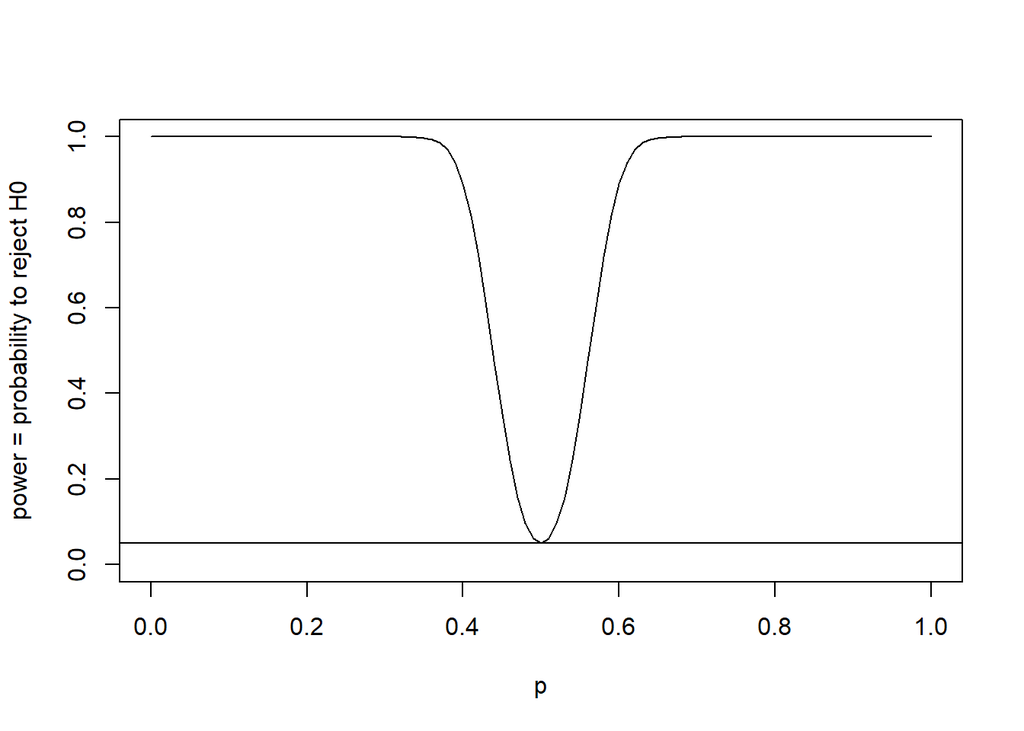

#### 7.3.0.1 Exercise

Reproduce the power plot. You can use ${\tt abline(h=0.05)}$ to add a straight line to the plot.

**Click for the answer**

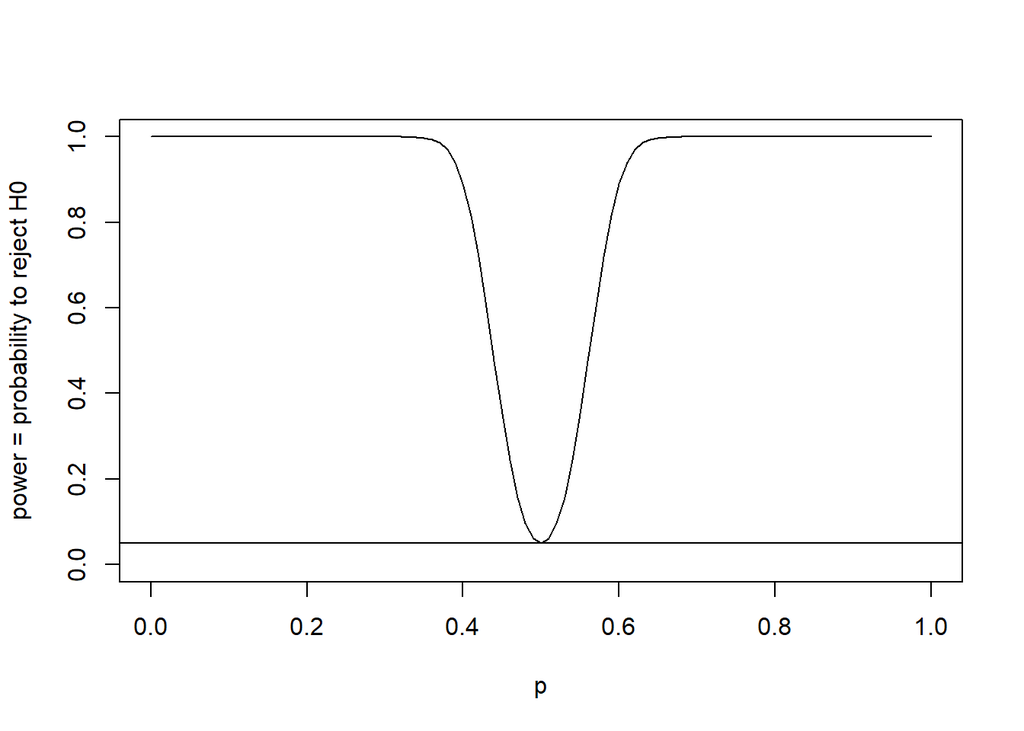

```r
p=seq(0,1,0.01)
power=pbinom(109,250,p)+1-pbinom(140,250,p)
plot(p,power,ylab='power = probability to reject H0',type='l',ylim=c(0,1))
abline(0.05,0)
```

$~$

In the Figure, we see that the probability to reject $H_0$ dips just below 0.05 when $p=1/2$. We designed our test that way! The probability of rejecting the null hypothesis must be below 0.05 when it is actually true. However, for all *other* values of $p$ (when the null hypothesis is not true), we *want* to reject $H_0$, so the power should be large. Of course, small deviations from the null hypothesis are difficult to detect. If $p=0.51$ then we have very little power. On the other hand, if $p=0.7$ then we have almost 100% power.

#### 7.3.0.2 Exercise

Use ${\tt pbinom}$ to compute the power to detect $p=0.51$ and $p=0.7$. Also, use simulation to compute the power approximately.

**Click for the answer**

```r
p=0.51
power=pbinom(109,250,p)+1-pbinom(140,250,p)
power
```

```
## [1] 0.06118538
```

```r
p=0.7
power=pbinom(109,250,p)+1-pbinom(140,250,p)
power
```

```
## [1] 0.999998
```

```r
# now use simulation
p=0.51
x=rbinom(10^6,250,p)
t=abs(x-125)  # test statistic
mean(t>15)
```

```
## [1] 0.060984
```

```r
p=0.7
x=rbinom(10^6,250,p)
t=abs(x-125)  # test statistic
mean(t>15)
```

```
## [1] 1
```

$~$

#### 7.3.0.3 Exercise

Suppose we perform a one-sided test, and reject the null hypothesis if $X > 138$. Use ${\tt lines(...,col='red')}$ to plot the power function of this test on top of the power function you plotted before. Think about what you see.

**Click for the answer**

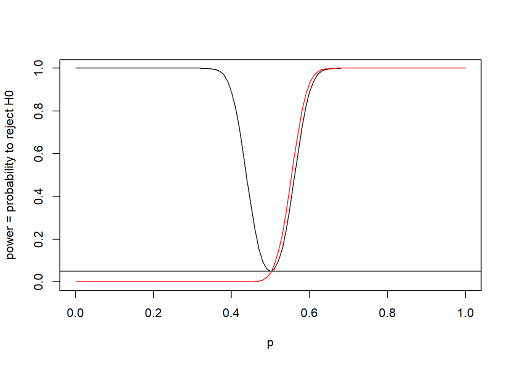

```r
p=seq(0,1,0.01)
power=pbinom(109,250,p)+1-pbinom(140,250,p)
plot(p,power,ylab='power = probability to reject H0',type='l',ylim=c(0,1))
abline(0.05,0)

power=1-pbinom(138,250,p)  # power of the one-sided test
lines(p,power,col='red')
```

$~$

A test is designed to have good power against certain alternatives. The one-sided test is good at detecting if the probability of heads is greater than 1/2, but it is not good at detecting if it is less than 1/2.

#### 7.3.0.4 Exercise

A coin is tossed 10 times to test the hypothesis that the probability of heads is 1/2. We reject the null hypothesis if either 0 or 10 heads are observed. Use ${\tt dbinom}$ and/or ${\tt pbinom}$ to compute the following:

1. What is the probability to make a type I error?
2. What is the level of significance?
3. What is the probability to make a type II error if the probability of heads is $0.3$?
4. What is the power of the test if the probability of heads is $0.3$?
5. Plot the power function.

**Click for the answer**

```r
alpha=dbinom(0,10,1/2)+dbinom(10,10,1/2)       # prob of type I
                                               # = level of significance = 0.002
alpha
```

```
## [1] 0.001953125
```

```r
beta=1 - (dbinom(0,10,0.3)+dbinom(10,10,0.3))  # prob of type II = 0.97
beta
```

```
## [1] 0.9717466
```

```r
power=dbinom(0,10,0.3)+dbinom(10,10,0.3)       # power = 0.03
power
```

```
## [1] 0.02825343
```

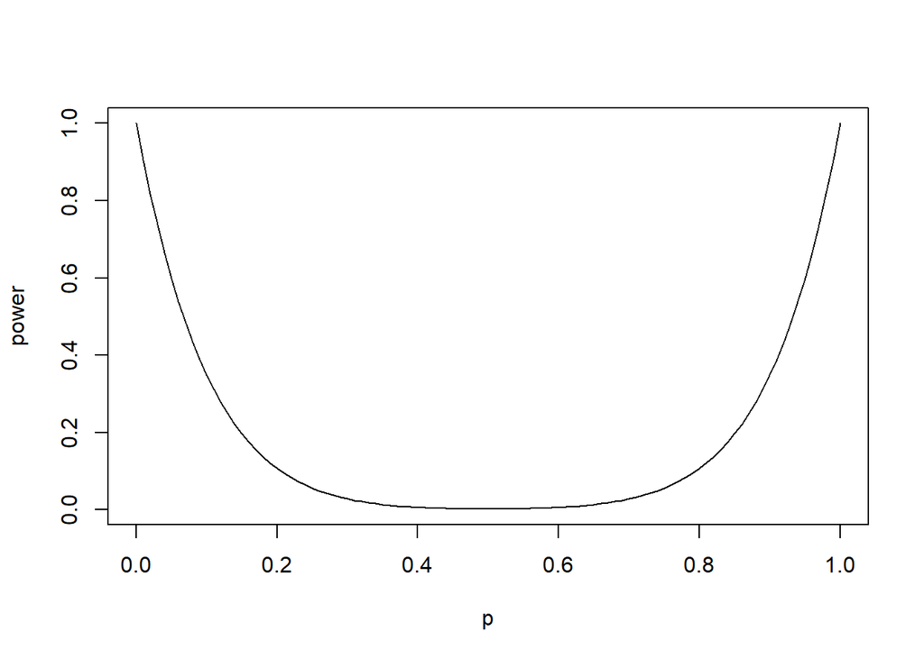

```r
# to plot the power function:
p=seq(0,1,0.01)
power=dbinom(0,10,p)+dbinom(10,10,p)
plot(p,power,type="l")
```

$~$

#### 7.3.0.5 Exercise

Repeat parts a-d of the the previous Exercise, but now use simulation.That is, you must use `rbinom`.

**Click for the answer**

```r
# a/b

reject=0
for (i in 1:10000){
  x=rbinom(1,10,0.5)    # p=0.5, so H0 is true
  reject = reject + (x==0 | x==10)
}
                        # this is the type I error prob
reject/10000            # a.k.a. level of significance
```

```
## [1] 0.0025
```

```r
# c.

reject=0
for (i in 1:10000){
  x=rbinom(1,10,0.3)    # p=0.3, so H0 is NOT true
  reject = reject + (x==0 | x==10)
}
reject/10000            # this is the power
```

```
## [1] 0.0299
```

```r
1 - reject/10000        # this is the type II error prob
```

```
## [1] 0.9701
```

$~$

#### 7.3.0.6 Exercise

Suppose we throw a die 102 times and get 23 sixes. This seems a little bit suspicious, because we would expect only 102/6=17 sixes. We decide to test if the die is fair.

1. Formulate the appropriate null hypothesis and alternative.
2. Which test statistic do you use to test the null hypothesis?
3. Suppose we want to test at level $\alpha=0.05$ what is the critical value for your test statistic?
4. Do you reject the null hypothesis at the 5% level of significance?
5. What is the power of the test if the probability of throwing a six is in fact 1/5?
6. Plot the power function.

**Click for the answer**

If you suspect that the die is loaded specifically to produce too many sizes, then you might want to do a one-sided test. The answers below are all for the *two-sided* test.

1. H0 : p=1/6 versus A : p is not 1/6
2. If X is the number of sixes, then we use |X - 17| as our test statistic (note that 102/6=17). We reject H_0 when this exceeds some K.
3. To find the appropriate ciritcal value, let’s try tem out:

```r
for (K in 0:10){
   alpha=pbinom(17-K-1,102,1/6) + 1 - pbinom(17+K,102,1/6)
   cat(K,alpha,'\n')
}
```

```
## 0 0.8945427
## 1 0.6907131
## 2 0.5068024
## 3 0.3520218
## 4 0.2306909
## 5 0.1422558
## 6 0.08242068
## 7 0.04488035
## 8 0.0230348
## 9 0.01121241
## 10 0.005224877
```

We see that K=7 is the smallest such that the level of significance does not exceed 5%.

4. Since we got 23 sixes, we have |17-23|=6 and so we do not reject.
5. The power to detect p=1/5 is:

```r
K=7
power=pbinom(17-K-1,102,1/5) + 1 - pbinom(17+K,102,1/5)  # power =  0.15
power
```

```
## [1] 0.1567949
```

6. To plot the power function:

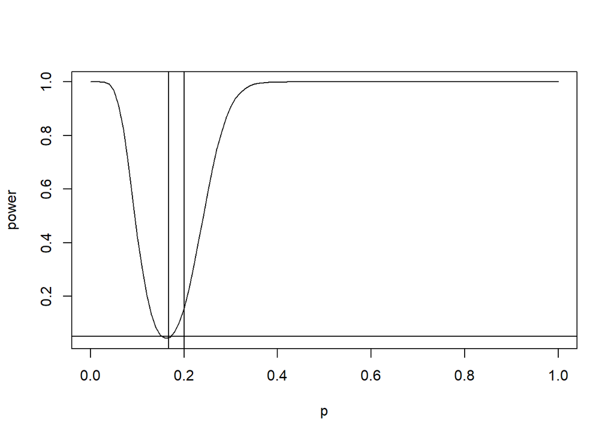

```r
p=seq(0,1,0.01)
K=7
power=pbinom(17-K-1,102,p) + 1 - pbinom(17+K,102,p)
plot(p,power,type="l")
abline(h=0.05)
abline(v=1/6)   # here's the null hypothesis p=1/6
abline(v=1/5)   # here's the alternative p=1/5
```

$~$

In the previous exercise, you computed the power to detect that the probability of throwing a six with a loaded die is $1/5$. This power is quite low. This makes sense, because the difference between 1/6 and 1/5 is not very great.

If we want more power, we can increase the level of significance. That means we “allow” more type I errors to bring down the type II errors.

#### 7.3.0.7 Exercise

Continuing the previous Exercise, suppose we want to test at level $\alpha=0.1$. Recompute the critical value, and recompute the power to detect $p=1/5$.

**Click for the answer**

```r
for (K in 0:10){
   alpha=pbinom(17-K-1,102,1/6) + 1 - pbinom(17+K,102,1/6)
   cat(K,alpha,'\n')
}
```

```
## 0 0.8945427
## 1 0.6907131
## 2 0.5068024
## 3 0.3520218
## 4 0.2306909
## 5 0.1422558
## 6 0.08242068
## 7 0.04488035
## 8 0.0230348
## 9 0.01121241
## 10 0.005224877
```

We see that choosing K=6 gives a valid test at level 10%. If we choose K=6, then the power against p=1/5 becomes

```r
K=6
power=pbinom(17-K-1,102,1/5) + 1 - pbinom(17+K,102,1/5)
power
```

```
## [1] 0.2228226
```

$~$

Increasing the level of significance it not always acceptable. Suppose we want to increase the power, but we are unwilling to increase the level of significance. We have two options:

1. Think of a better test statistic. In this case, that is provably impossible.
2. Get a bigger sample size

#### 7.3.0.8 Exercise

Continuing the previous Exercise, suppose we insist on level $\alpha=0.05$. We throw the dice an additional 102 times and get another 20 sixes. So, we have 20+23=43 sixes in 204 tosses. Recompute the critical value, and recompute the power to detect $p=1/5$.

**Click for the answer**

If the die is fair, then we expect 34 sixes in 204 tosses. Our test statistic becomes |X - 34|

```r
for (K in 0:10){
   alpha=pbinom(34-K-1,204,1/6) + 1 - pbinom(34+K,204,1/6)
   cat(K,alpha,'\n')
}
```

```
## 0 0.9252414
## 1 0.7782973
## 2 0.6388159
## 3 0.5109577
## 4 0.3977953
## 5 0.3011178
## 6 0.2214162
## 7 0.1580298
## 8 0.1094127
## 9 0.07345784
## 10 0.04782085
```

We see that choosing K=10 gives a valid test at level 5%. If we choose K=10, then the power against p=1/5 becomes 25%

```r
K=10
power=pbinom(34-K-1,204,1/5) + 1 - pbinom(34+K,204,1/5)
power
```

```
## [1] 0.2560256
```

#### 7.3.0.9 Exercise

Find a thumb tack. Suppose you toss it in the air and let it drop to the ground.

1. What do think the probability is that it lands with the point up? This will be your null hypothesis.
2. Design an experiment and decide on which test you will use.
3. Plot the power curve for your test.
4. Perform the experiment and do the test.

**Click for the answer**

You (should) know what to do now!

$~$ `

## 7.4 Normal approximation

We have seen how we can perform a statistical test of an hypothesis about the probability of success in a binomial experiment. It is not difficult to do the calculations using ${\tt dbinom}$ and ${\tt pbinom}$. However, we will now discuss an approximation that is used very often in practice.

If the sample size $n$ is large, and the probability $p$ not too close to zero or one, then the binomial distribution with parameters $n$ and $p$ is well approximated by the normal distribution with the same mean and variance. Recall that the binomial distribution has mean $np$ and variance $np(1-p)$.

#### 7.4.0.1 Exercise

Don’t take my word for it! Use the code below to try it out for different $n$ and $p$. What happens when $n$ is small? And when $p$ is close to zero or 1?

**Click for the answer**

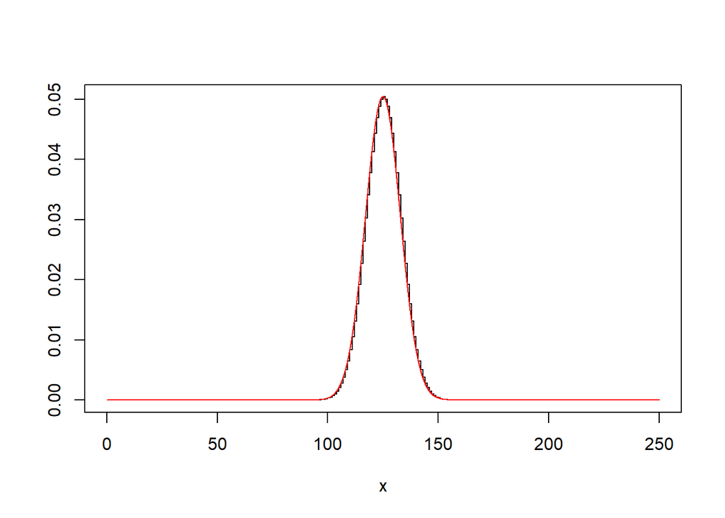

```r
n=250;
p=0.5;
x=0:n
plot(x,dbinom(x,n,p),type="s",ylab='')

x=seq(0,n,0.01)
lines(x,dnorm(x,n*p,sqrt(n*p*(1-p))),col='red')
```

When n is small or p is close to 0 or 1, you can see that the normal approximation is not good. For example,

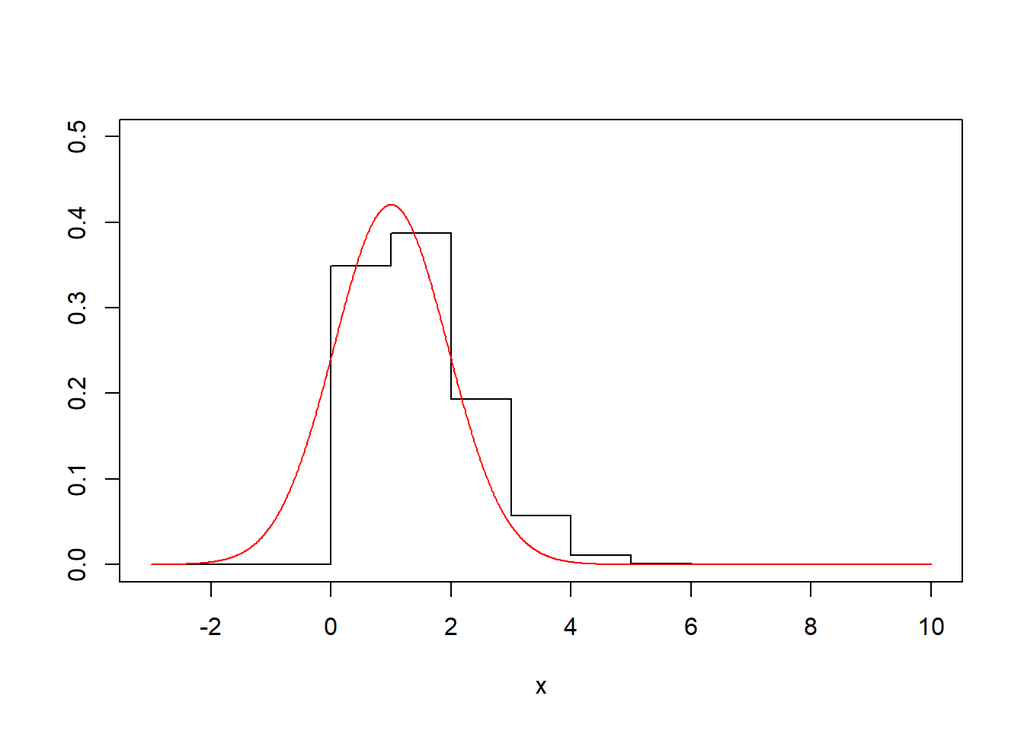

```r
n=10;
p=0.1;
x=-3:n
plot(x,dbinom(x,n,p),type="s",ylab='',xlim=c(-3,10),ylim=c(0,0.5))
x=seq(-3,n,0.01)
lines(x,dnorm(x,n*p,sqrt(n*p*(1-p))),col='red')
```

$~$

Now recall the Polish coin tossing experiment. If the null hypothesis is true ($p=1/2$), then the number of heads (approximately) has the normal distribution with mean $125$ and variance $250 \cdot \frac12 \cdot (1-\frac12)=62.5$. So, if the null distribution is true, then
$$Z=\frac{X - 125}{\sqrt{62.5}}$$
(approximately) has the standard normal distribution (with mean=0 and standard deviation=1). We reject the null distribution if $|Z|$ exceeds some threshold $K$. We need to determine $K$ such that the probability of rejecting the null hypothesis when it is true does not exceed $\alpha=0.05$. We can use the quantile function of the normal distribution which in ${\tt R}$ is called ${\tt qnorm}$.

```r
K=qnorm(0.975,0,1)
K
```

```
## [1] 1.959964
```

In other words, we can approximately do the hypothesis at level 5% (two-sided) by rejecting when $|Z|>1.96$.

#### 7.4.0.2 Exercise

Make sure you understand that the quantile function ${\tt qnorm}$ and the cumulative distribution function ${\tt pnorm}$ are each others inverse.

**Click for the answer**

With the cumulative distribution function, we choose a number and get the probability of drawing less than that number. For example, if X is standard normal, then P(X < 1.96)=0.975

```r
pnorm(1.96,0,1)
```

```
## [1] 0.9750021
```

With the quantile function, we input some probability (number between 0 and 1) and get the number back:

```r
qnorm(0.975,0,1)
```

```
## [1] 1.959964
```

So, the CDF (such as `pnorm`) and the quantile function (such as `qnorm`) are each other’s *inverse*.

$~$

#### 7.4.0.3 Exercise

Compute the $Z$ statistic for the Polish data. Do you reject the null hypothesis at level $\alpha=0.05$? Do you reject it at $\alpha=0.1$?

**Click for the answer**

$Z=(140 - 125)/\sqrt{62.5}=1.9$. Since 1.9 is less than 1.96, we do not reject the null hypothesis at alpha=0.05.

$~$

To test at level alpha=0.1, we must compare |Z| with qnorm(0.95,0,1)=1.64. Since 1.9 is greater than 1.64 we reject the null hypothesis at level alpha=0.1.

$~$

## 7.5 What have we learned: hypothesis testing

Suppose we have an independent sample $X_1,X_2,\dots,X_n$ from some probability distribution. Hypothesis testing is a decision problem: We have to decide if our probability distribution is among a set of probability distributions $H_0$ (null hypothesis) or a set of probability distributions $H_1$ (alternative hypothesis). The null hypothesis $H_0$ gets the benefit of doubt; we reject it only if it is very unlikely that any distribution from $H_0$ could have produced our data.

We formalize this as follows. Specify some event $R$ that is unlikely to happen if $H_0$ is true, and then reject $H_0$ if $R$ does occur. The event $R$ almost always has the form of a test statistic exceeding some critical value.

If $H_0$ is true and $R$ occurs, we make a type I error. The probability of a type I error is called the level of significance or $\alpha$ for short. Typically, we choose $R$ in such a way that $\alpha$ does not exceed 0.05.

If $H_0$ is *not* true and $R$ does *not* occur, then we make a type II error.

The power of a test at particular probability distribution, is the probability of $R$ under that probability distribution. The power must not exceed $\alpha$ for distributions in $H_0$, while a good test has large power at distributions in $H_1$.

So, to test some null hypothesis at significance level $\alpha$, we can follow this recipe:

> 1. Choose a *test statistic* $T$, which a random variable (a function of the data) that you expect to have large values if the null hypothesis is false, and small values if the null hypothesis is true.
> 2. Find the distribution of $T$ when the null hypothesis is true. You can do this either analytically or by simulation.
> 3. Find the *critical value* $t_\alpha$, which is the $(1-\alpha)$-quantile of the distribution of $T$ under the null hypothesis.
> 4. If the observed $T$ is larger than the critical value $t_\alpha$, reject the null hypothesis.

# 8 Confidence intervals

## 8.1 Some familiar and some unfamiliar tests

We have discussed the normal approximation to the binomial test of a proportion. There is also a normal approximation to the test for a difference of two proportions. This approximation is called the chi-squared test, or $\chi^2$ test

Consider, the following situation. A Belgian euro is tossed 250 times and 140 heads are obtained. Then a Dutch euro is tossed 20 times and 7 heads are obtained. Is there a significant difference between the probability of heads of the two coins at level $\alpha=0.05$? We start by construct a 2x2 contingency table:

```r
Observed = matrix(c(140,110,7,13),nrow=2,byrow=TRUE)
Observed
```

```
##      [,1] [,2]
## [1,]  140  110
## [2,]    7   13
```

*If* the probability of heads is the same in both experiments, then we would estimate it as $\hat p = 147/270$. With this estimate, we can compute the *expected* table if both probabilities were the same.

```r
Expected = matrix(c(136.1,113.9,10.9,9.1),nrow=2,byrow=TRUE)
Expected
```

```
##       [,1]  [,2]
## [1,] 136.1 113.9
## [2,]  10.9   9.1
```

Now we compute a test statistic that becomes large when the expected table differs from the observed table.
$$X^2 = \sum_{i=1}^4 \frac{(O_i - E_i)^2}{E_i} =
\frac{(140-136.1)^2}{136.1} + \frac{(110 - 113.9)^2}{113.9} + \frac{(7-10.9)^2}{10.9} + \frac{(13-9.1)^2}{9.1}=3.3$$

In R, we can do

```r
X2=sum((Observed - Expected)^2/Expected)
X2
```

```
## [1] 3.312136
```

Under $H_0$ our test statistic $X^2$ has the chi-squared distribution with one degree of freedom. Here’s the density of this distribution

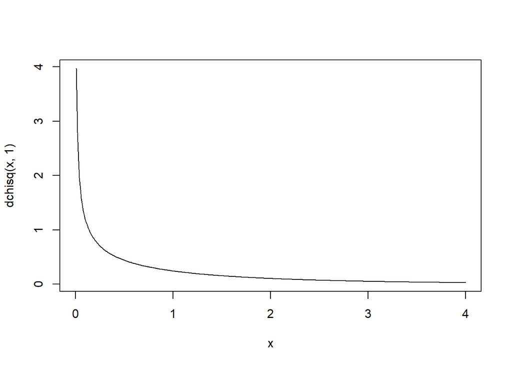

```r
x=seq(0,4,0.01)
plot(x,dchisq(x,1),type="l")
```

The critical value for testing at level $\alpha=0.05$ is

```r
qchisq(0.95,1)
```

```
## [1] 3.841459
```

Since `X2`=3.3 is less than `qchisq(0.95,1)`=3.8, we do NOT reject $H_0$ at $\alpha=0.05$.

#### 8.1.0.1 Exercise

Suppose that 160 patients are divided randomly into two groups of 80. The patients in the first group are given some treatment, and 30 of the 80 recover from their illness. In the other group, the patients are given a placebo, and only 20 recover. So, we have the following 2x2 table

```r
Observed = matrix(c(30,50,20,60),nrow=2,byrow=TRUE)
Observed
```

```
##      [,1] [,2]
## [1,]   30   50
## [2,]   20   60
```

Test the hypothesis that there is no difference between the treatment and placebo at 5% level of significance. Also, test at 10% level of significance.

**Click for the answer**

Under the null hypothesis (no difference) we estimate the probability of recovery at p=50/160. So, the 2x2 table of expected counts is

```r
p=50/160
Expected = matrix(c(80*p,80*(1-p),80*p,80*(1-p)),nrow=2,byrow=TRUE)
Expected
```

```
##      [,1] [,2]
## [1,]   25   55
## [2,]   25   55
```

The chi-squared statistic is

```r
X2=sum((Observed - Expected)^2/Expected)
X2
```

```
## [1] 2.909091
```

The critical value for testing at level 5% is

```r
qchisq(0.95,1)
```

```
## [1] 3.841459
```

$~$

The critical value for testing at level 10% is

```r
qchisq(0.9,1)
```

```
## [1] 2.705543
```

Since X2=2.9 is greater than qchisq(0.9,1)=2.7, we reject the null at alpha=10%.

$~$

The $\chi^2$ test extends easily to tables with $n$ rows and $m$ columns, but we shall not discuss that here.

### 8.1.1 $Z$ test for the mean

Suppose we have an iid sample from a normal distribution with unknown mean $\mu$ and *known* variance $\sigma^2$. We want to test
$$H_0 : \mu = \mu_0 \quad \text{versus}\quad A : \mu \neq \mu_0$$
at level $\alpha$ for some fixed value $\mu_0$. We can base our test on
$$Z = \frac{\bar X - \mu_0}{\sigma/\sqrt{n}}.$$
If $H_0$ is true, then $Z$ has the standard normal distribution. So, to test at level $\alpha$, we may compare $Z$ to the $(1-\alpha/2) \times 100\%$ quantile of the standard normal distribution.

#### 8.1.1.1 Exercise

Suppose a supermarket sells potatoes in 1 kilo bags. We buy 7 bags and weigh them. We find 983, 1041, 1026, 1025, 1033, 968 and 1028 (grams). We know that the standard deviation of the weight is 25 grams. We want to test
$$H_0 : \mu = 1000 \quad \text{versus}\quad A : \mu \neq 1000$$
at level $\alpha=0.05$.

1. Compute the $Z$ statistic.
2. What is the critical value for your test statistic?
3. Do you reject the null hypothesis?
4. What is the power when true mean weight is actually 980 grams?
5. Plot the power function.

**Click for the answer**

```r
x=c(983,1041,1026,1025,1033,968,1028)
z=sqrt(7)*(mean(x)-1000)/25    # z statistic
z
```

```
## [1] 1.572332
```

2. So far, we determined the critical value K by trial-and-error. Here we use the quantile function:

$~$ If H0 is true, then Z has the standard normal distribution.

- If |Z| < K then we do *not* reject
- So, we want P(|Z| < K)=0.95, when Z has the standard normal distribution.
- So, we want P(Z < K)=0.975, when Z has the standard normal distribution.
- So, K=qnorm(0.975,0,1)

```r
K=qnorm(0.975,0,1)
K
```

```
## [1] 1.959964
```

3. Since |z|=1.57 is less than K=qnorm(0.975,0,1)=1.96, we do NOT reject.
4. We reject if |Z| > K where Z = sqrt(7) * (Xbar - 1000)/25. To compute the power, we need to know the probability that this happens when mu=980. Note:
   $$\begin{align*}
   Z &= \sqrt{7}\frac{\bar X - 1000}{25} \\
   &= \sqrt{7}\frac{\bar X - 980}{25} + \sqrt{7}\frac{-20}{25} \\
   &= \sqrt{7}\frac{\bar X - 980}{25} - 2.12
   \end{align*}$$
   So, if mu=980, then Z has the normal distribution with mean -2.12 and standard deviation 1. The probability that |Z|>1.96 becomes

```r
power=pnorm(-1.96,-2.12,1) + (1 - pnorm(1.96,-2.12,1))
power
```

```
## [1] 0.563582
```

To plot the power

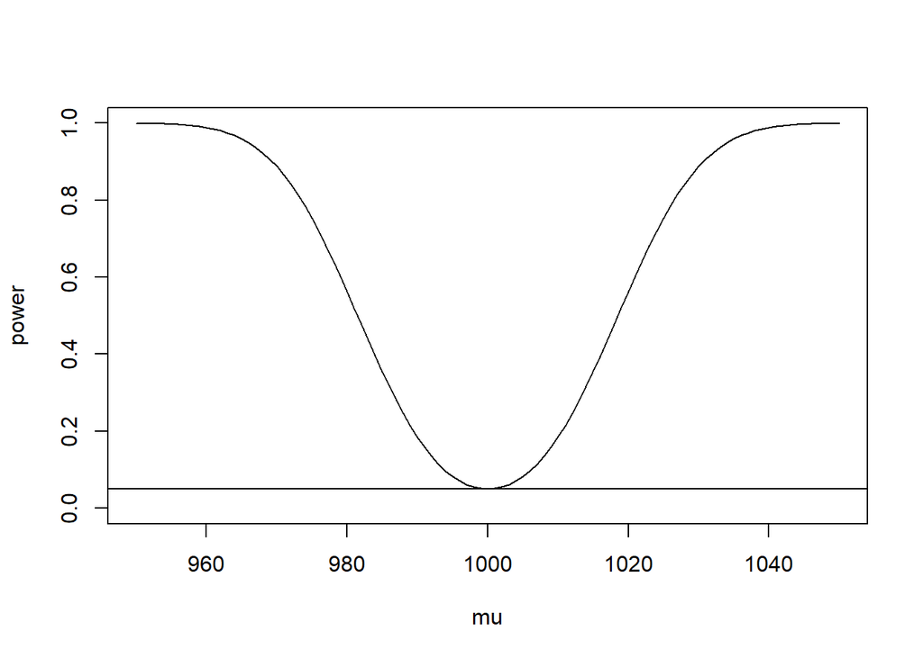

```r
mu=950:1050                       # mean of X
meanZ = sqrt(7) * (mu - 1000)/25  # mean of Z

power=pnorm(-1.96,meanZ,1) + (1 - pnorm(1.96,meanZ,1))
plot(mu,power,type='l',ylim=c(0,1))
abline(h=0.05)
```

$~$